# DACFE_Data_Analysis

## True Choice

### Descriptive

```r
df_True_Choice <-
  df_True_Choice %>%
  mutate(ChoiceDemand_code = ifelse(ChoiceDemand == "Easy", 1, 0))
```

```r
df_true_dc_props_easy <-
  df_True_Choice %>%
  group_by(PID) %>%
  summarise(DEC_prop_true = mean(ChoiceDemand_code, na.rm=TRUE), .groups = "drop") %>%
  mutate(DemandAvoidance_true = ifelse(DEC_prop_true > 0.5, "demand_avoid", "no_demand_avoid"))
```

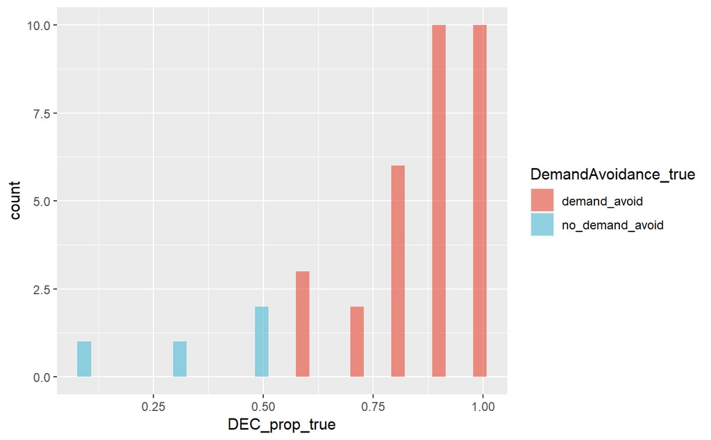

```r
df_true_dc_props_easy %>%
  ggplot(aes(x=DEC_prop_true, fill=DemandAvoidance_true))+
  geom_histogram(alpha=0.6)+
  scale_fill_npg()
```

```r
table(df_true_dc_props_easy$DemandAvoidance_true)
```

```
   demand_avoid no_demand_avoid
             31               4
```

```r
# ggplot(df_true_dc_props_easy, aes(x="", y = DCERs_true, label=PID)) +
df_true_dc_props_easy %>%
  # group_by(DemandAversive) %>%
  # ggplot(data = ., aes(x=DemandAversive_on, y = DEC_prop_true)) +
  ggplot(data = ., aes(x="", y = DEC_prop_true)) +
  geom_boxplot(position="identity", width = 0.4) +
  geom_point(aes(group = PID, color=DemandAvoidance_true),
             alpha = 0.8, position = position_dodge2(width = 0.15)) +
  geom_hline(aes(yintercept = 0.5, linetype = "Chance Level") ,color = "red") +
  geom_hline(aes(yintercept = mean(DEC_prop_true, na.rm = TRUE), linetype = "Mean") ,color = "blue") +
  scale_linetype_manual(name = "Lines", values = c(2, 2),
                      guide = guide_legend(override.aes = list(color = c("red", "blue"))))+
  stat_boxplot(geom = "errorbar", width = 0.15) +
  scale_y_continuous(limits = c(0, 1), n.breaks = 10) +
  # geom_text_repel(aes(color=DemandAvoidance_true), max.overlaps = nrow(df_true_dc_props_easy)) +
  scale_color_d3()+
  labs(title = "Easy Choice Probability in True Choice Phase",
       x="DemandAversive",
       # x="",
       y = "P(Easy Choice)") +
  theme_bw() +
  theme(plot.title = element_text(hjust = 0.5),
        axis.text.x = element_text(size = 5))
```

```r
w_prop_true <-
  df_true_dc_props_easy %>%
  wilcox_test(DEC_prop_true ~ 1, mu=.5, alternative = "greater", detailed = TRUE) %>%
  add_significance()
```

group by DemandAversive

```r
w_prop_true_by_aversive_on <-
  df_true_dc_props_easy %>%
  group_by(DemandAversive_on) %>%
  wilcox_test(DEC_prop_true ~ 1, mu=.5, alternative = "greater", detailed = TRUE) %>%
  add_significance()
# significantly > 0.5 among aversive group
```

### Choice Curves

All

```r
df_true_dc_props_easy_by_trial <-
  df_True_Choice %>%
  group_by(PID) %>%
  mutate(DEC_prop_true = cummean(ChoiceDemand_code)) %>%
  mutate(DemandAvoidance_false = ifelse(DEC_prop_true > 0.5, "demand_avoid", "no_demand_avoid"))
```

```r
df_true_dc_props_easy_by_trial_mean <-
  df_true_dc_props_easy_by_trial %>%
  group_by(TrialN) %>%
  summarise(DEC_prop_true_mean = mean(DEC_prop_true, na.rm = TRUE), .groups = "drop")
```

```r
df_true_dc_props_easy_by_trial_mean %>%
  ggplot(aes(x=TrialN, y=DEC_prop_true_mean))+
  geom_line(linewidth = 0.7)+
  geom_point(shape=17)+
  # scale_color_d3()+
  geom_hline(aes(yintercept = 0.5, linetype = "Chance Level") ,color = "red")+
  geom_hline(aes(yintercept = mean(DEC_prop_true_mean, na.rm = TRUE),
                 linetype = "Mean across TrialN"),color = "blue")+
  scale_linetype_manual(name = "Lines", values = c(2, 2),
                      guide = guide_legend(override.aes = list(color = c("red", "blue"))))+
  geom_boxplot(data=df_true_dc_props_easy_by_trial,
               aes(x=TrialN, y=DEC_prop_true, group = TrialN),
               width = 0.35, outlier.shape = 8, alpha = 0.3)+
  geom_point(data=df_true_dc_props_easy_by_trial,
               aes(x=TrialN, y=DEC_prop_true, group = TrialN,
                   color = ChoiceDemand),
               position = position_dodge2(width = 0.35), alpha = 0.3)+
  scale_color_lancet() +
  stat_boxplot(data=df_true_dc_props_easy_by_trial,
               aes(x=TrialN, y=DEC_prop_true, group = TrialN),
               geom = "errorbar", width = 0.15) +
  scale_x_continuous(limits = c(0, 11), n.breaks = 10, expand = c(0,0))+
  scale_y_continuous(limits = c(0, 1), n.breaks = 10)+
  labs(title = "Easy Choice Probability in True Choice Phase", x="TrialN", y = "P(Easy Choice)")+
  theme_bw()+
  theme(plot.title = element_text(hjust = 0.5),
        axis.text.x = element_text(size = 5))
```

```r
df_true_dc_props_easy_by_trial_mean %>%
  ggplot(aes(x=TrialN, y=DEC_prop_true_mean))+
  geom_line(linewidth = 0.7)+
  geom_point()+
  geom_point(data=df_true_dc_props_easy_by_trial,
               aes(x=TrialN, y=DEC_prop_true, group = TrialN, color = factor(PID)),
               position = position_dodge2(width = 0.15), size = 0.5 ,alpha = 0.3)+
  geom_line(data=df_true_dc_props_easy_by_trial,
               aes(x=TrialN, y=DEC_prop_true, color = factor(PID)),
            linetype = "dotted", alpha = 0.5)+
  geom_hline(aes(yintercept = 0.5, linetype = "Chance Level") ,color = "red")+
  geom_hline(aes(yintercept = mean(DEC_prop_true_mean, na.rm = TRUE),
                 linetype = "Mean across TrialN"),color = "blue")+
  scale_linetype_manual(name = "Lines", values = c(2, 2),
                      guide = guide_legend(override.aes = list(color = c("red", "blue"))))+
  scale_x_continuous(limits = c(0, 11), n.breaks = 10, expand = c(0,0))+
  scale_y_continuous(limits = c(0, 1), n.breaks = 10)+
  labs(title = "Easy Choice Probability in True Choice Phase", x="TrialN", y = "P(Easy Choice)")+
  theme_bw()+
  theme(plot.title = element_text(hjust = 0.5),
        axis.text.x = element_text(size = 5))
```

### fEMG (CAREFUL! most trials are Easy?)

```r
indi_box_plot(df_True_Choice, "cue_e_true_zyg_zvalues", "ChoiceDemand",
              FALSE, FALSE)
indi_box_plot(df_True_Choice, "cue_e_true_cor_zvalues", "ChoiceDemand",
              FALSE, FALSE)
indi_box_plot(df_True_Choice, "cue_e_true_scr_zvalues", "ChoiceDemand",
              FALSE, FALSE)
```

```r
indi_curve_plot <- function(df_clean, indicator, gb1, gb2){
  m = max(df_clean[gb1])
  df_clean %>%
  group_by(!!sym(gb1), !!sym(gb2)) %>%
  summarise(phy_z = mean(!!sym(indicator), na.rm=TRUE), .groups = "drop") %>%
  ggplot(aes(x=!!sym(gb1), y=phy_z, color=!!sym(gb2)))+
  geom_line()+
  geom_point()+
  scale_color_lancet()+
  scale_x_continuous(breaks = seq(1, m))+
  theme_bw()
}
```

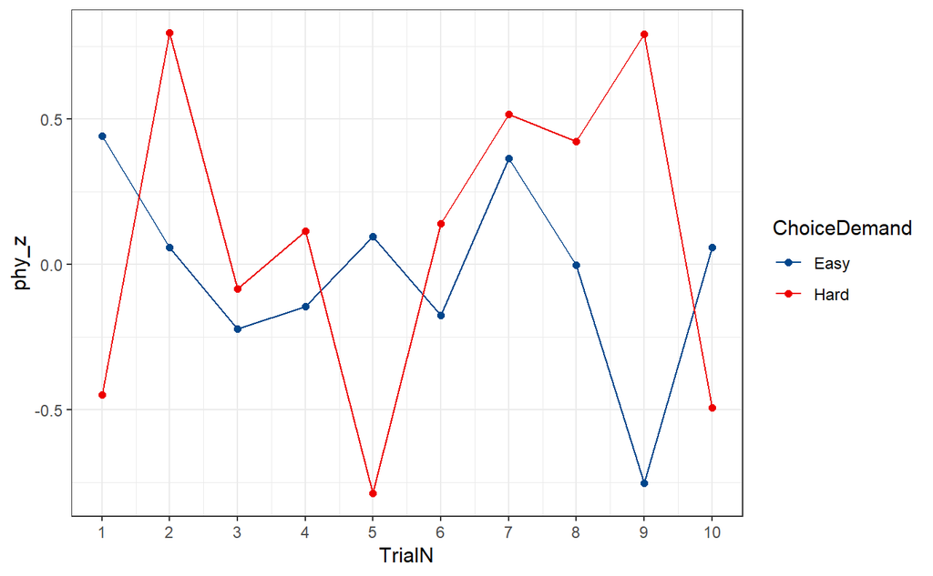

```r
indi_curve_plot(df_True_Choice, "cue_e_true_zyg_zvalues",
                "TrialN", "ChoiceDemand")
```

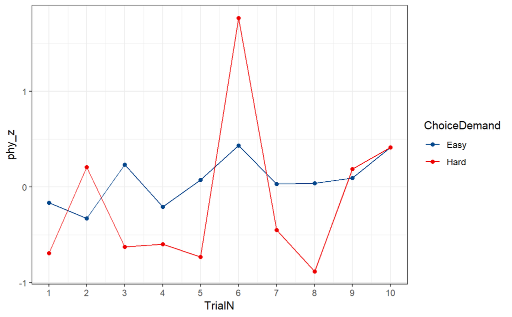

```r
indi_curve_plot(df_True_Choice, "cue_e_true_cor_zvalues",
                "TrialN", "ChoiceDemand")
```

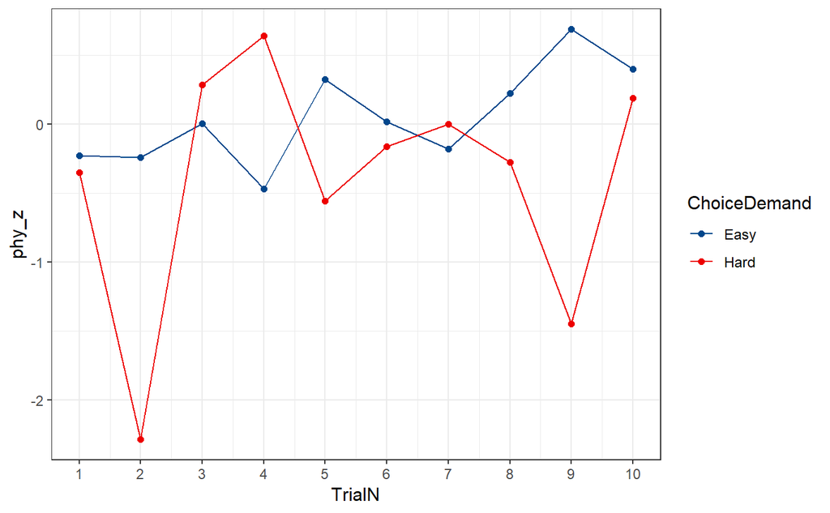

```r
indi_curve_plot(df_True_Choice, "cue_e_true_scr_zvalues",
                "TrialN", "ChoiceDemand")
```

## False Choice

### Descriptive

```r
df_False_Choice <-
  df_False_Choice %>%
  mutate(ChoiceDemand_code = ifelse(ChoiceDemand == "Easy", 1, 0))
```

```r
df_false_dc_props_easy <-
  df_False_Choice %>%
  group_by(PID) %>%
  summarise(DEC_prop_false = mean(ChoiceDemand_code, na.rm=TRUE), .groups = "drop") %>%
  mutate(DemandAvoidance_false = ifelse(DEC_prop_false > 0.5, "demand_avoid", "no_demand_avoid"))
```

```r
# df_false_dc_props_easy$PID[df_false_dc_props_easy$DEC_prop_false==0]
```

```r
table(df_false_dc_props_easy$DemandAvoidance_false)
```

```
   demand_avoid no_demand_avoid
             22              13
```

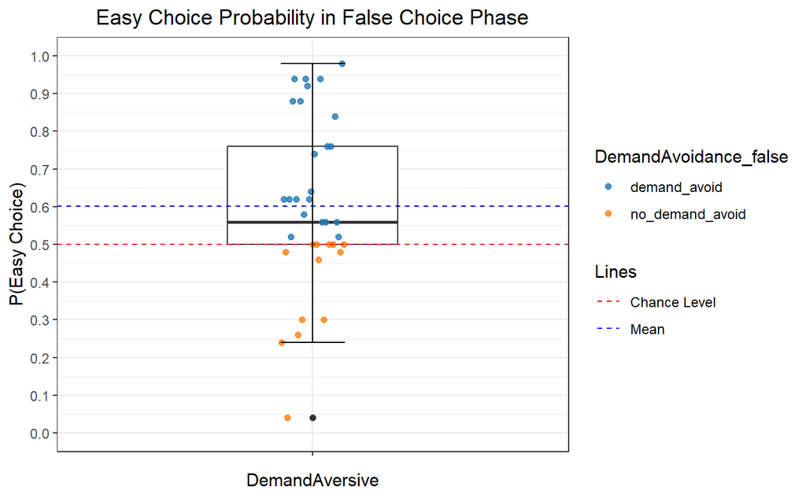

```r
# ggplot(df_true_dc_props_easy, aes(x="", y = DCERs_true, label=PID)) +
df_false_dc_props_easy %>%
  # group_by(DemandAversive) %>%
  # ggplot(data = ., aes(x=DemandAversive_on, y = DEC_prop_true)) +
  ggplot(data = ., aes(x="", y = DEC_prop_false)) +
  geom_boxplot(position="identity", width = 0.4) +
  geom_point(aes(group = PID, color=DemandAvoidance_false),
             alpha = 0.8, position = position_dodge2(width = 0.15)) +
  geom_hline(aes(yintercept = 0.5, linetype = "Chance Level") ,color = "red") +
  geom_hline(aes(yintercept = mean(DEC_prop_false, na.rm = TRUE), linetype = "Mean") ,color = "blue") +
  scale_linetype_manual(name = "Lines", values = c(2, 2),
                      guide = guide_legend(override.aes = list(color = c("red", "blue"))))+
  stat_boxplot(geom = "errorbar", width = 0.15) +
  scale_y_continuous(limits = c(0, 1), n.breaks = 10) +
  # geom_text_repel(aes(color=DemandAvoidance_true), max.overlaps = nrow(df_true_dc_props_easy)) +
  scale_color_d3()+
  labs(title = "Easy Choice Probability in False Choice Phase",
       x="DemandAversive",
       # x="",
       y = "P(Easy Choice)") +
  theme_bw() +
  theme(plot.title = element_text(hjust = 0.5),
        axis.text.x = element_text(size = 5))
```

```r
df_false_dc_props_easy_10 <-
  df_False_Choice %>%
  filter(TrialN %in% c(1:10)) %>%
  group_by(PID) %>%
  summarise(DEC_prop_false = mean(ChoiceDemand_code, na.rm=TRUE), .groups = "drop") %>%
  mutate(DemandAvoidance_false = ifelse(DEC_prop_false > 0.5, "demand_avoid", "no_demand_avoid"))

table(df_false_dc_props_easy_10$DemandAvoidance_false)
```

```
   demand_avoid no_demand_avoid
             22              13
```

```r
df_false_dc_props_easy_50 <-
  df_False_Choice %>%
  filter(TrialN %in% c(41:50)) %>%
  group_by(PID) %>%
  summarise(DEC_prop_false = mean(ChoiceDemand_code, na.rm=TRUE), .groups = "drop") %>%
  mutate(DemandAvoidance_false = ifelse(DEC_prop_false > 0.5, "demand_avoid", "no_demand_avoid"))

table(df_false_dc_props_easy_50$DemandAvoidance_false)
```

```r
w_prop_false_ <-
  df_false_dc_props_easy %>%
  wilcox_test(DEC_prop_false ~ 1, mu=.5, alternative = "greater", detailed = TRUE) %>%
  add_significance()
```

### False Choice Learning Curve

Accumulated proportion by trialN

```r
df_false_dc_props_easy_by_trial <-
  df_False_Choice %>%
  group_by(PID) %>%
  mutate(DEC_prop_false = cummean(ChoiceDemand_code)) %>%
  mutate(DemandAvoidance_false = ifelse(DEC_prop_false > 0.5, "demand_avoid", "no_demand_avoid"))
```

```r
df_false_dc_props_easy_by_trial_mean <-
  df_false_dc_props_easy_by_trial %>%
  group_by(TrialN) %>%
  summarise(DEC_prop_false_mean = mean(DEC_prop_false, na.rm = TRUE), .groups = "drop")
```

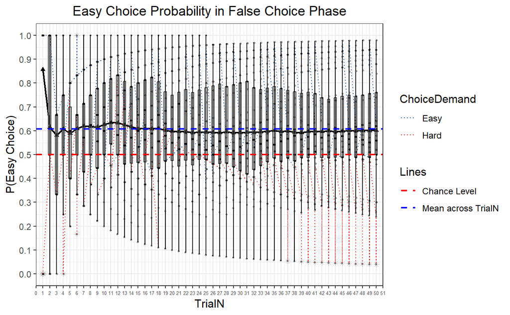

```r
df_false_dc_props_easy_by_trial_mean %>%
  ggplot(aes(x=TrialN, y=DEC_prop_false_mean))+
  geom_line(linewidth=0.7)+
  geom_point(shape=17)+
  geom_boxplot(data=df_false_dc_props_easy_by_trial,
               aes(x=TrialN, y=DEC_prop_false, group = TrialN),
               width = 0.35, outlier.shape = 8, alpha = 0.3)+
  geom_point(data=df_false_dc_props_easy_by_trial,
               aes(x=TrialN, y=DEC_prop_false, group = TrialN),
               position = position_dodge2(width = 0.15), size = 0.5 ,alpha = 0.3)+
  geom_line(data=df_false_dc_props_easy_by_trial,
               aes(x=TrialN, y=DEC_prop_false, color = ChoiceDemand),
            linetype = "dotted")+
  stat_boxplot(data=df_false_dc_props_easy_by_trial,
               aes(x=TrialN, y=DEC_prop_false, group = TrialN),
               geom = "errorbar", width = 0.15) +
  geom_hline(aes(yintercept = 0.5, linetype = "Chance Level"),
             color = "red", linewidth = 0.7)+
  geom_hline(aes(yintercept = mean(DEC_prop_false_mean, na.rm = TRUE), linetype = "Mean across TrialN"),
             color = "blue", linewidth = 0.7)+
  scale_linetype_manual(name = "Lines", values = c(2, 2),
                      guide = guide_legend(override.aes = list(color = c("red", "blue"))))+
  scale_color_lancet()+
  scale_x_continuous(limits = c(0, 51), n.breaks = 50, expand = c(0,0))+
  scale_y_continuous(limits = c(0, 1), n.breaks = 10)+
  labs(title = "Easy Choice Probability in False Choice Phase", x="TrialN", y = "P(Easy Choice)")+
  theme_bw()+
  theme(plot.title = element_text(hjust = 0.5),
        axis.text.x = element_text(size = 5))
```

group by Demand Aversive

```r
df_false_dc_props_easy_by_trial_mean_by_aversive <-
  df_false_dc_props_easy_by_trial %>%
  group_by(TrialN, DemandAversive) %>%
  summarise(DEC_prop_false_mean = mean(DEC_prop_false, na.rm = TRUE), .groups = "drop")
```

```r
df_false_dc_props_easy_by_trial_mean_by_aversive %>%
  ggplot(aes(x=TrialN, y=DEC_prop_false_mean, group = DemandAversive))+
  geom_hline(aes(yintercept = 0.5, linetype = "Chance Level"),
             color = "red", linewidth = 0.7)+
  geom_hline(aes(yintercept = mean(DEC_prop_false_mean[DemandAversive == "demand_aversive"], na.rm = TRUE),
                 linetype = "Mean-Aversive"), # Mean across TrialN of Aversive group
             color = "blue", linewidth = 0.7)+
  geom_hline(aes(yintercept = mean(DEC_prop_false_mean[DemandAversive == "no_demand_aversive"], na.rm = TRUE),
                 linetype = "Mean-No-Aversive"), #Mean across TrialN of No-Aversive group
             color = "orange", linewidth = 0.7)+
  scale_linetype_manual(name = "Lines", values = c(2, 2, 2),
                      guide = guide_legend(override.aes = list(color = c("red", "blue", "orange"))))+
  geom_boxplot(data=df_false_dc_props_easy_by_trial_v2,
               aes(x=TrialN, y=DEC_prop_false, group = TrialN),
               width = 0.35, outlier.shape = 8, alpha = 0.3)+
  geom_point(data=df_false_dc_props_easy_by_trial_v2,
               aes(x=TrialN, y=DEC_prop_false, group = TrialN, color = ChoiceDemand),
               position = position_dodge2(width = 0.15), size = 0.5 ,alpha = 0.3)+
  # geom_line(data=df_false_dc_props_easy_by_trial_v2,
  #              aes(x=TrialN, y=DEC_prop_false),
  #           linetype = "dotted")+
  stat_boxplot(data=df_false_dc_props_easy_by_trial_v2,
               aes(x=TrialN, y=DEC_prop_false, group = TrialN),
               geom = "errorbar", width = 0.15) +
  geom_line(linewidth=0.7)+
  geom_point(shape=17)+
  scale_color_lancet()+
  facet_wrap(~DemandAversive)+
  scale_x_continuous(limits = c(0, 51), n.breaks = 50, expand = c(0,0))+
  scale_y_continuous(limits = c(0, 1), n.breaks = 10)+
  labs(title = "Easy Choice Probability in False Choice Phase", x="TrialN", y = "P(Easy Choice)")+
  theme_bw()+
  theme(plot.title = element_text(hjust = 0.5),
        axis.text.x = element_text(size = 5))
```

each participant

```r
df_false_dc_props_easy_by_trial_v2_mean_by_aversive %>%
  ggplot(aes(x=TrialN, y=DEC_prop_false_mean))+
  geom_boxplot(data=df_false_dc_props_easy_by_trial_v2,
               aes(x=TrialN, y=DEC_prop_false, group = TrialN),
               width = 0.35, outlier.shape = 8, alpha = 0.3)+
  geom_point(data=df_false_dc_props_easy_by_trial_v2,
               aes(x=TrialN, y=DEC_prop_false, group = TrialN),
               position = position_dodge2(width = 0.15), size = 0.5 ,alpha = 0.3)+
  geom_line(data=df_false_dc_props_easy_by_trial_v2,
               aes(x=TrialN, y=DEC_prop_false, color = factor(PID)),
            linetype = "dotted")+
  stat_boxplot(data=df_false_dc_props_easy_by_trial_v2,
               aes(x=TrialN, y=DEC_prop_false, group = TrialN),
               geom = "errorbar", width = 0.15) +
  geom_line(linewidth=0.7)+
  geom_point(shape=17)+
  geom_hline(aes(yintercept = 0.5, linetype = "Chance Level"),
             color = "red", linewidth = 0.7)+
  geom_hline(aes(yintercept = mean(DEC_prop_false_mean, na.rm = TRUE), linetype = "Mean across TrialN"),
             color = "blue", linewidth = 0.7)+
  scale_linetype_manual(name = "Lines", values = c(2, 2),
                      guide = guide_legend(override.aes = list(color = c("red", "blue"))))+
  facet_wrap(~DemandAversive)+
  scale_x_continuous(limits = c(0, 51), n.breaks = 50, expand = c(0,0))+
  scale_y_continuous(limits = c(0, 1), n.breaks = 10)+
  labs(title = "Easy Choice Probability in False Choice Phase", x="TrialN", y = "P(Easy Choice)")+
  theme_bw()+
  theme(plot.title = element_text(hjust = 0.5),
        axis.text.x = element_text(size = 5))
```

#### Separate Proportions by sections (10 trials)

```r
# review the number of easy and hard trials in each trial section
# it turns out to be relatively balanced
result_table <-
  df_Flase_Choice %>%
  mutate(Trial_N_Group = cut(TrialN, breaks = c(1, 10, 20, 30, 40, 50), labels = FALSE)) %>%
  # mutate(Trial_N_Group = cut(TrialN, breaks = c(1,5,10,15,20,25,30,35,40,45,50), labels = FALSE)) %>%
  group_by(PID, Trial_N_Group) %>%
  summarise(DEC_prop_false = mean(ChoiceDemand_code, na.ra = TRUE), .groups = "drop")

# Print the resulting table
# print(result_table)
```

```r
section_DEC_res <- function(df_clean, gb, col_resp, sections, plot=FALSE){
  # Create a function to calculate mean for each section of trials
  section_means <- function(df_clean, col_resp, section){
    df <-
      df_clean %>%
        group_by(PID) %>%
        summarise(across((col_resp),
                         ~ mean(.[TrialN %in% section], na.rm = TRUE),
                         .names = "indi_mean"), .groups = "drop")
  }
  # Initialize an empty list to store the results
  result_list <- list()

  # Use lapply to iterate over each section and calculate means
  result_list <- lapply(names(sections), function(section_name) {
    section <- trial_sections[[section_name]]

    # Calculate means for the current section
    result <- section_means(df_clean, col_resp, section)

    # Add a column indicating the section name
    result$Section <- section_name

    return(result)
    })
    # Combine the results into a single data frame
    df_indi_means_demands_tsecs <- bind_rows(result_list)


    if(plot){
      df_indi_means_demands_tsecs %>%
        ggplot(aes(x = Section, y = indi_mean)) +
        geom_boxplot(position = "dodge2",
                     alpha = 0.7, width = 0.5, outlier.color = "black") +
        geom_jitter(position = position_dodge(width = 0.75), alpha = 0.5) +
        scale_color_lancet() +
        stat_summary(fun = mean, geom = "point", aes(group = Section),
                 shape = 17, color="black", size = 2,
               position = position_dodge(width = 0.5)) +
        # stat_pvalue_manual(t_indi_set, label = "p = {p}{p.signif}", hide.ns = FALSE,
        #                     tip.length = 0, linetype = "blank") +
        labs(title = "DEC by Section", y=col_resp) +
        theme_bw() +
        theme(plot.title = element_text(hjust = 0.5))
    }else{
      return(df_indi_means_demands_tsecs)
    }
}
```

[figure not shown]

```r
section_DEC_res(df_False_Choice, NA,"ChoiceDemand_code",
            trial_sections, plot=TRUE)
```

```r
NA
NA
```

#### lines plot of false choice rates in easy and hard demands

```r
# Create a function to calculate mean for each section of trials
calculate_section_means <- function(df, col_reps, section, gb=NA) {
  if(!is.na(gb)){
    df %>%
    group_by(PID, !!sym(gb)) %>%
    summarise(across(starts_with(col_reps),
                     ~ mean(.[TrialN %in% section], na.rm = TRUE),
                     .names = "indi_mean"), .groups = "drop")
  }else{
    df %>%
    group_by(PID) %>%
    summarise(across(starts_with(col_reps),
                     ~ mean(.[TrialN %in% section], na.rm = TRUE),
                     .names = "indi_mean"), .groups = "drop")
  }
}

# Define the sections
trial_sections <- list("10" = 1:10, "20" = 11:20, "30" = 21:30, "40" = 31:40, "50" = 41:50)
# trial_sections <- list("05" = 1:5, "10" = 6:10,
#                        "15" = 11:15, "20" = 16:20,
#                        "25" = 21:25, "30" = 26:30,
#                        "35" = 31:35, "40" = 36:40,
#                        "45" = 41:45, "50" = 46:50)

# Initialize an empty list to store the results
result_list <- list()
# Use lapply to iterate over each section and calculate means
result_list <- function(df,trial_sections, indicator, gb=NA){
  lapply(names(trial_sections), function(section_name) {
  section <- trial_sections[[section_name]]

  # Calculate means for the current section
  result <- calculate_section_means(df, indicator, section, gb)

  # Add a column indicating the section name
  result$Section <- section_name

  return(result)
})
  }
```

```r
# Combine the results into a single data frame
df_false_dc_prop_means_de_sec <-
  bind_rows(result_list(df_False_Choice,trial_sections ,"ChoiceDemand_code")) %>%
  mutate(DemandAvoidance_false = ifelse(indi_mean > 0.5, "demand_avoid", "no_demand_avoid")) %>%
  merge(df_off_ra_means_de_diff[df_off_ra_means_de_diff$OfflineRatingTimePoint=="T2", c("PID", "DemandAversive_off")], by = "PID", all.x = T)
```

```r
df_false_dc_prop_grandmeans_de_sec <-
  df_false_dc_prop_means_de_sec %>%
  group_by(Section) %>%
  summarise(indi_gmean = mean(indi_mean, na.rm = TRUE), .groups = "drop")
```

points in different colors of each participant

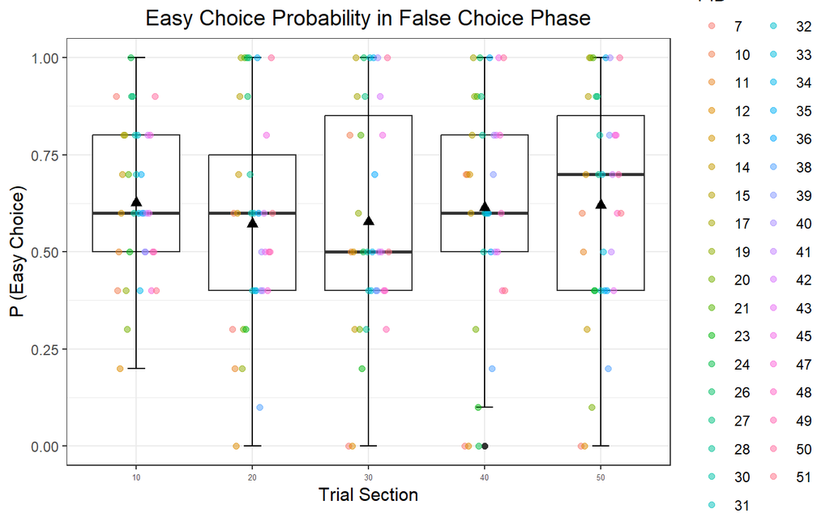

```r
df_false_dc_prop_means_de_sec %>%
  ggplot(aes(x = Section, y = indi_mean))+
  geom_boxplot(position = position_dodge(width = 0.5))+
  stat_boxplot(geom = "errorbar", width = 0.15) +
  geom_jitter(
    aes(color = factor(PID)),
    position = position_dodge(width = 0.35), alpha = 0.5)+
  stat_summary(fun = "mean", shape = 17)+
  labs(title = "Easy Choice Probability in False Choice Phase",
       x="Trial Section", y = "P (Easy Choice)", color = "PID") +
  theme_bw() +
  theme(plot.title = element_text(hjust = 0.5),
        axis.text.x = element_text(size = 5))
```

grand means of participants in each trial section

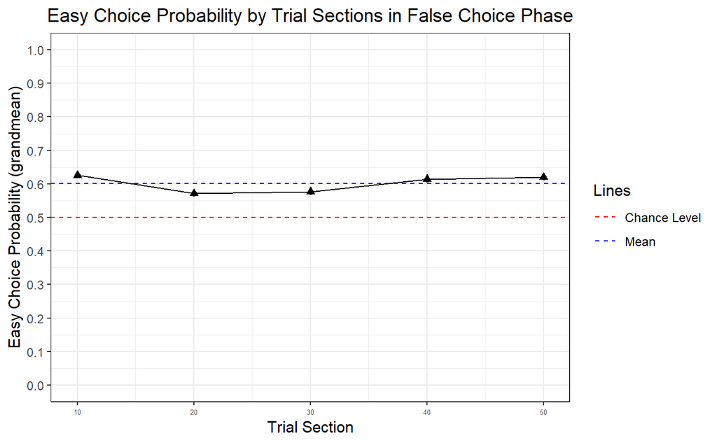

```r
df_false_dc_prop_grandmeans_de_sec %>%
  mutate(TrialSection = as.numeric(Section)) %>%
  ggplot(aes(x = TrialSection, y = indi_gmean)) +
  geom_point() +
  geom_line() +
  geom_hline(aes(yintercept = 0.5, linetype = "Chance Level"), color = "red") +
  geom_hline(aes(yintercept = mean(df_false_dc_prop_means_de_sec$indi_mean, na.rm = TRUE),
             linetype = "Mean"), color = "blue") +
        geom_point(position = position_dodge(width = 0.5), alpha = 0.5) +
        scale_color_lancet() +
        stat_summary(fun = mean, geom = "point",
                 shape = 17, color="black", size = 2,
               position = position_dodge(width = 0.5)) +
  # scale_x_continuous(breaks = c(5,10,15,20,25,30,35,40,45,50))+

  scale_x_continuous(breaks = c(10,20,30,40,50))+
  scale_y_continuous(limits = c(0, 1), n.breaks = 10)+
  labs(title = "Easy Choice Probability by Trial Sections in False Choice Phase",
       x = "Trial Section", y = "Easy Choice Probability (grandmean)") +
  scale_linetype_manual(name = "Lines", values = c(2, 2),
                      guide = guide_legend(override.aes = list(color = c("red", "blue"))))+
  theme_bw() +
  theme(plot.title = element_text(hjust = 0.5),
        axis.text.x = element_text(size = 5))
```

The first 10 trials

```r
df_false_dc_means_demands_tsecs_v2 %>%
  filter(Section == 10) %>%
  ggplot(aes(x="", y=DEC_prop_false))+
  geom_boxplot(position="identity", width = 0.4)+
  geom_point(position = position_dodge2(width = 0.15), aes(color = DemandAvoidance_false))+
  stat_boxplot(geom = "errorbar", width = 0.15)+
  scale_color_d3()+
  geom_hline(aes(yintercept = 0.5, linetype = "Chance Level"),color = "red")+
  geom_hline(aes(yintercept = mean(DEC_prop_false, na.rm = TRUE),
                 linetype = "Mean") ,color = "blue")+
  scale_linetype_manual(name = "Lines", values = c(2, 2),
                      guide = guide_legend(override.aes = list(color = c("red", "blue"))))+
  scale_y_continuous(limits = c(0, 1), n.breaks = 10)+
  labs(title = "Easy Choice Probability in False Choice Phase 1-10 Trials", x="", y = "P(Easy Choice)")+
  theme_bw()+
  theme(plot.title = element_text(hjust = 0.5),
        axis.text.x = element_text(size = 5))
```

Identify participants without exploration in first 10 trials

```r
no_explore_pid <-
  df_false_dc_means_demands_tsecs_v2 %>%
  filter(PID %in% PID[Section == 10 & DEC_prop_false == 1]) %>%
  dplyr::select(PID)
no_explore_pid <- unique(as.numeric(no_explore_pid$PID))

df_false_dc_means_demands_tsecs_v2_explored <-
  df_false_dc_means_demands_tsecs_v2 %>%
  filter(!PID %in% no_explore_pid)

df_false_dc_grandmeans_demands_tsecs_v2_explored <-
  df_false_dc_means_demands_tsecs_v2_explored %>%
  group_by(Section) %>%
  summarise(DEC_prop_false_gmean = mean(DEC_prop_false, na.rm = TRUE), .groups = "drop")
```

```r
# Plot
df_false_dc_grandmeans_demands_tsecs_v2_explored %>%
  mutate(TrialSection = as.numeric(Section)) %>%
  ggplot(aes(x = TrialSection, y = DEC_prop_false_gmean)) +
  geom_point() +
  geom_line() +
  geom_hline(aes(yintercept = 0.5, linetype = "Chance Level"), color = "red") +
  geom_hline(aes(yintercept = mean(df_false_dc_means_demands_tsecs_v2_explored$DEC_prop_false, na.rm = TRUE),
             linetype = "Mean across TrialN"), color = "blue") +
  # scale_x_continuous(breaks = c(5,10,15,20,25,30,35,40,45,50))+
  scale_x_continuous(breaks = c(10,20,30,40,50))+
  # scale_y_continuous(limits = c(0, 1), n.breaks = 10)+
  labs(title = "\n Easy Choice Probability by Trial Sections in False Choice Phase \n
       (exclude participants without exploration in 1st section)",
       x = "Trial Section", y = "Easy Choice Probability (grandmean)") +
  scale_linetype_manual(name = "Lines", values = c(2, 2),
                      guide = guide_legend(override.aes = list(color = c("red", "blue"))))+
  theme_bw() +
  theme(plot.title = element_text(hjust = 0.5),
        axis.text.x = element_text(size = 5))
```

group by Demand Aversive

```r
df_false_dc_grandmeans_demands_tsecs_v2_by_aversive_on <-
  df_false_dc_means_demands_tsecs_v2 %>%
  group_by(Section, DemandAversive_on) %>%
  summarise(DEC_prop_false_gmean = mean(DEC_prop_false, na.rm = TRUE), .groups = "drop")
```

```r
df_false_dc_grandmeans_demands_tsecs_v2_by_aversive %>%
  mutate(TrialSection = as.numeric(Section)) %>%
  ggplot(aes(x = TrialSection, y = DEC_prop_false_gmean)) +
  geom_point() +
  geom_line() +
  geom_hline(aes(yintercept = 0.5, linetype = "Chance Level"), color = "red") +
  geom_hline(aes(yintercept = mean(DEC_prop_false_gmean[DemandAversive == "demand_aversive"], na.rm = TRUE),
             linetype = "Mean-Aversive"), color = "blue") +
  geom_hline(aes(yintercept = mean(DEC_prop_false_gmean[DemandAversive == "no_demand_aversive"], na.rm = TRUE),
             linetype = "Mean-No-Aversive"), color = "orange") +
  # scale_x_continuous(breaks = c(5,10,15,20,25,30,35,40,45,50))+
  scale_x_continuous(breaks = c(10,20,30,40,50))+
  scale_y_continuous(limits = c(0, 1), n.breaks = 10)+
  labs(title = "Easy Choice Probability by Trial Sections in False Choice Phase",
       x = "Trial Section", y = "Easy Choice Probability (grandmean)") +
  scale_linetype_manual(name = "Lines", values = c(2, 2, 2),
                      guide = guide_legend(override.aes = list(color = c("red", "blue", "orange"))))+
  facet_wrap(~DemandAversive)+
  theme_bw() +
  theme(plot.title = element_text(hjust = 0.5),
        axis.text.x = element_text(size = 5))
```

### fEMG

```r
indi_hist_plot(df_False_Choice, "cue_e_false_zyg_zvalues", "ChoiceDemand")
indi_hist_plot(df_False_Choice, "cue_e_false_cor_zvalues", "ChoiceDemand")
indi_hist_plot(df_False_Choice, "cue_e_false_scr_zvalues", "ChoiceDemand")
```

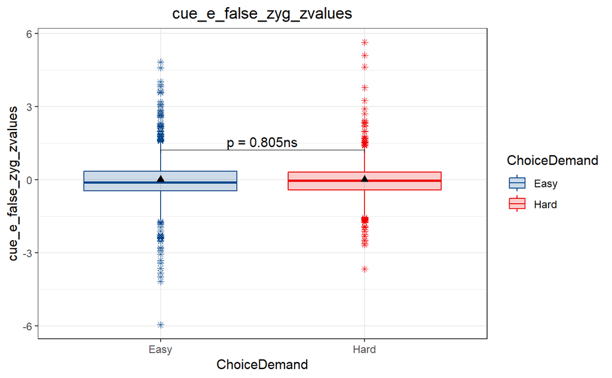

```r
indi_box_plot(df_False_Choice, "cue_e_false_zyg_zvalues", "ChoiceDemand",
              FALSE, FALSE)
```

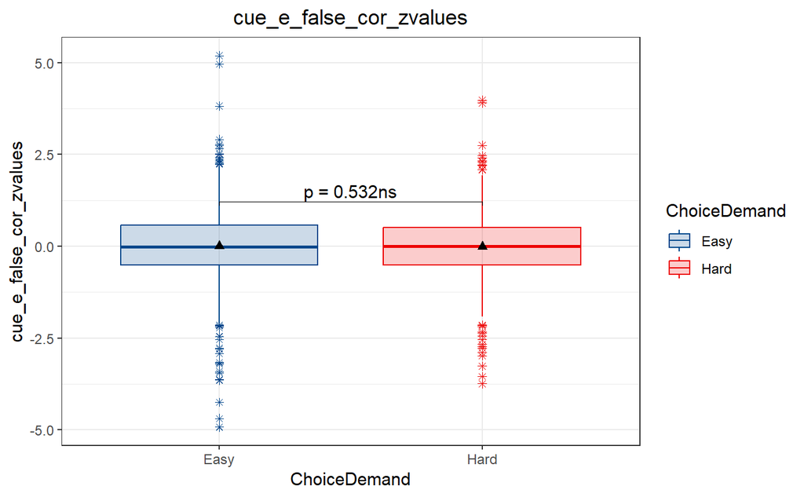

```r
indi_box_plot(df_False_Choice, "cue_e_false_cor_zvalues", "ChoiceDemand",
              FALSE, FALSE)
```

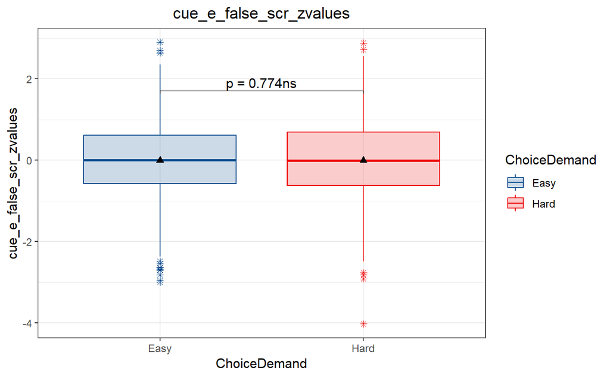

```r
indi_box_plot(df_False_Choice, "cue_e_false_scr_zvalues", "ChoiceDemand",
              FALSE, FALSE)
```

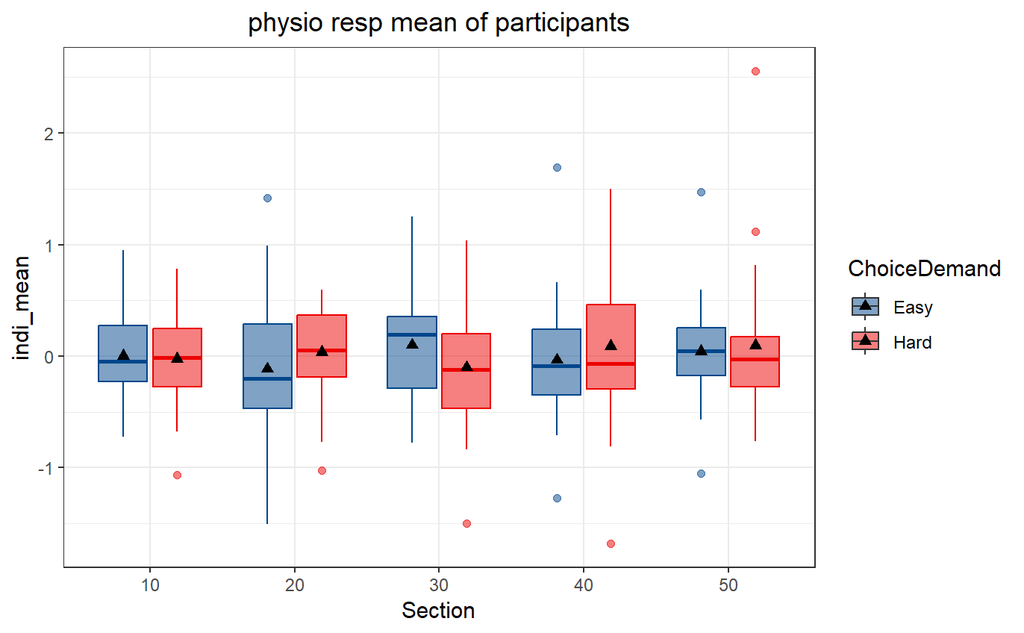

```r
# Combine the results into a single data frame
df_false_phy_means_de_sec <-
  bind_rows(result_list(df = df_False_Choice,trial_sections,
                       "cue_e_false_zyg_zvalues", "ChoiceDemand")) %>%
  merge(df_off_ra_means_de_diff[df_off_ra_means_de_diff$OfflineRatingTimePoint=="T2", c("PID", "DemandAversive_off")], by = "PID", all.x = T)
df_false_phy_means_de_sec %>%
  ggplot(aes(x = Section, y=indi_mean,
             color  = ChoiceDemand, fill = ChoiceDemand)) +
  geom_boxplot(alpha=0.5)+
  # scale_x_continuous(breaks = seq(-5, 5)) +
  stat_summary(fun = mean, geom = "point",
                 shape = 17, size = 2, color="black",
               position = position_dodge(width = 0.75)) +
  scale_color_lancet() +
  scale_fill_lancet() +
  labs(title = "physio resp mean of participants") +
  guides(color = "none") +
  theme_bw() +
  theme(plot.title = element_text(hjust = 0.5))
```

```r
df_false_phy_grandmeans_de_sec <-
  df_false_phy_means_de_sec %>%
  group_by(Section) %>%
  summarise(indi_gmean = mean(indi_mean, na.rm = TRUE), .groups = "drop")
```

```r
# use for correlation analysis
df_false_dc_prop_means_de_sec_wide <-
  df_false_dc_prop_means_de_sec %>%
  dplyr::select(-DemandAvoidance_false) %>%
  pivot_wider(names_from = Section, values_from = DEC_prop_false, names_prefix = "DEC_prop_false_") %>%
  # mutate(DEC_prop_false_drop = DEC_prop_false_10 - DEC_prop_false_50) %>%
  merge(df_off_ra_means_de_diff[df_off_ra_means_de_diff$OfflineRatingTimePoint=="T2", c("PID", "DemandAversive_off")], by = "PID", all.x = T)
```

```r
w_prop_false_sec1_v2 <-
  df_false_dc_means_demands_tsecs_wide %>%
  wilcox_test(DEC_prop_false_10 ~ 1, mu=.5, alternative = "greater", detailed = TRUE) %>%
  add_significance()

w_prop_false_sec2_v2 <-
  df_false_dc_means_demands_tsecs_wide %>%
  wilcox_test(DEC_prop_false_20 ~ 1, mu=.5, alternative = "greater", detailed = TRUE) %>%
  add_significance()

w_prop_false_sec3_v2 <-
  df_false_dc_means_demands_tsecs_wide %>%
  wilcox_test(DEC_prop_false_30 ~ 1, mu=.5, alternative = "greater", detailed = TRUE) %>%
  add_significance()

w_prop_false_sec4_v2 <-
  df_false_dc_means_demands_tsecs_wide %>%
  wilcox_test(DEC_prop_false_40 ~ 1, mu=.5, alternative = "greater", detailed = TRUE) %>%
  add_significance()

# Section 5 became non-significant
w_prop_false_sec5_v2 <-
  df_false_dc_means_demands_tsecs_v2_wide %>%
  wilcox_test(DEC_prop_false_50 ~ 1, mu=.5, alternative = "greater", detailed = TRUE) %>%
  add_significance()
```

## Questionnaires

### Distribution of questionnaires data

```r
ques_indi_hist_plot <- function(df_clean, indicator){
  gghistogram(df_clean[[indicator]], bins = 15, fill = "lightblue")+
  geom_vline(xintercept = mean(df_clean[[indicator]], na.rm=TRUE),
             linetype="dashed", linewidth=0.7, color="darkblue")+
  labs(title = indicator, x="score", y = "Count")+
  theme_bw()+
  theme(plot.title = element_text(hjust = 0.5),
        axis.text.x = element_text(size = 5))
}

ques_indi_summary <- function(df_clean, indicator){
  indi_summary <-
    df_clean %>%
    summarise(indi_mean = mean(!!sym(indicator), na.rm=TRUE),
           indi_sd = sd(!!sym(indicator), na.rm=TRUE),
           indi_med = median(!!sym(indicator), na.rm=TRUE),
           indi_min = min(!!sym(indicator), na.rm=TRUE),
           indi_max = max(!!sym(indicator), na.rm=TRUE))
  return(indi_summary)
}
```

```r
Qs <- list("BAI_bis","BAI_bas_d","BAI_bas_rr","BAI_bas_fs",
        "NFC",
        "BFI_ext" ,"BFI_agr","BFI_con","BFI_neu","BFI_open",
        "UPPS_lps","UPPS_lpm","UPPS_pu","UPPS_ss")
for (q in Qs){
  p <- ques_indi_hist_plot(df_clean, q)
  print(p)
  }
```

## Correlations

```r
df_ra_dc <-
  merge(df_off_ra_means_de_diff, df_true_dc_props_easy, by="PID", all = TRUE) %>%
  merge(df_false_dc_props_easy, by="PID", all = TRUE) %>%
  merge(df_false_dc_prop_means_de_sec, by="PID", all = TRUE) %>%
  merge(df_on_phy_means_de, by="PID", all = TRUE) %>%
  merge(df_false_phy_means_de, by="PID", all = TRUE) %>%
  merge(df_clean, by="PID", all = TRUE)
```

```r
df_cors <-
  df_ra_dc %>%
  filter(OfflineRatingTimePoint.x=="T2") %>%
  select(OfflineRating_z_diff, cue_i_on_scr_zvalues.x)
cor(df_cors)
```

correlation matrix output

```r
ra_dc_cors_matrix_v2 <- rcorr(as.matrix(df_cors_pure_v2))
# write.csv(ra_dc_cors_matrix_v2$r,
#           file = "E:/Dissertation/Methods/Exp2_Demand_Choice/DARDCpy_v2/data_analysis/cors_matrix_r_v2.csv")
# write.csv(ra_dc_cors_matrix_v2[["P"]],
#           file = "E:/Dissertation/Methods/Exp2_Demand_Choice/DARDCpy_v2/data_analysis/cors_matrix_p_v2.csv")
```

```r
ra_dc_cors_v2 <- cor(df_cors_pure_v2)
print(ra_dc_cors_v2)
write.csv(ra_dc_cors_v2,
          file = "E:/Dissertation/Methods/Exp2_Demand_Choice/DARDCpy_v2/data_analysis/cors_v2.csv")


print("Online ~ True Choice")
bf <- correlationBF(df_cors_v2$OnlineRatingZs_diff, df_cors_v2$DCERs_true)
bf

print("Offline_T1 ~ True Choice")
bf <- correlationBF(df_cors_v2$OfflineRating_T1Zs_diff, df_cors_v2$DCERs_true)
bf

print("Offline_T2 ~ True Choice")
bf <- correlationBF(df_cors_v2$OfflineRating_T2Zs_diff, df_cors_v2$DCERs_true)
bf


print("Offline_T2 ~ False Choice")
bf <- correlationBF(df_cors_v2$OfflineRating_T2Zs_diff, df_cors_v2$DCERs_false)
bf

print("Offline_T3 ~ False Choice")
bf <- correlationBF(df_cors_v2$OfflineRating_T3Zs_diff, df_cors_v2$DCERs_false)
bf

# samples <- posterior(bf, iterations = 1000)
# summary(samples)
```

Scatter plots #### Online Rating ~ Offline Rating

```r
# ggplot(df_cors_v2, aes(x = OnlineRatingZs_diff, y = OfflineRating_T1Zs_diff, label = PID)) +
ggplot(df_cors_v2, aes(x = OnlineRatingZs_diff, y = OfflineRating_T1Zs_diff)) +
  geom_point() +
  geom_smooth(method = "lm") +
  stat_cor(method = "spearman")+
  # geom_text_repel(max.overlaps = nrow(df_cors_v2)) +
  labs(title = "Correlation: Online & Offline Rating T1",
       x = "Online Rating Diff (easy - hard)", y = "Offline Rating T1 Diff (easy - hard)") +
  theme_bw() +
  theme(plot.title = element_text(hjust = 0.5))


# ggplot(df_cors_v2, aes(x = OnlineRatingZs_diff, y = OfflineRating_T2Zs_diff, label = PID)) +
ggplot(df_cors_v2, aes(x = OnlineRatingZs_diff, y = OfflineRating_T2Zs_diff)) +
  geom_point() +
  geom_smooth(method = "lm") +
  stat_cor(method = "spearman")+
  # geom_text_repel(max.overlaps = nrow(df_cors_v2)) +
  labs(title = "Correlation: Online & Offline Rating T2",
       x = "Online Rating Diff (easy - hard)", y = "Offline Rating T2 Diff (easy - hard)") +
  theme_bw() +
  theme(plot.title = element_text(hjust = 0.5))


# ggplot(df_cors_v2, aes(x = OnlineRatingZs_diff, y = OfflineRating_T2Zs_diff, label = PID)) +
ggplot(df_cors_v2, aes(x = OnlineRatingZs_diff, y = OfflineRating_T3Zs_diff)) +
  geom_point() +
  geom_smooth(method = "lm") +
  stat_cor(method = "spearman")+
  # geom_text_repel(max.overlaps = nrow(df_cors_v2)) +
  labs(title = "Correlation: Online & Offline Rating T3",
       x = "Online Rating Diff (easy - hard)", y = "Offline Rating T3 Diff (easy - hard)") +
  theme_bw() +
  theme(plot.title = element_text(hjust = 0.5))


# ggplot(df_cors_v2, aes(x = OfflineRating_T1Zs_diff, y = OfflineRating_T2Zs_diff, label = PID)) +
ggplot(df_cors_v2, aes(x = OfflineRating_T1Zs_diff, y = OfflineRating_T2Zs_diff)) +
  geom_point() +
  geom_smooth(method = "lm") +
  stat_cor(method = "spearman")+
  # geom_text_repel(max.overlaps = nrow(df_cors_v2)) +
  labs(title = "Correlation: Offline Rating T1 & T2",
       x = "Offline Rating T1 Diff (easy - hard)", y = "Offline Rating T2 Diff (easy - hard)") +
  theme_bw() +
  theme(plot.title = element_text(hjust = 0.5))

# ggplot(df_cors_v2, aes(x = OfflineRating_T1Zs_diff, y = OfflineRating_T2Zs_diff, label = PID)) +
ggplot(df_cors_v2, aes(x = OfflineRating_T1Zs_diff, y = OfflineRating_T3Zs_diff)) +
  geom_point() +
  geom_smooth(method = "lm") +
  stat_cor(method = "spearman")+
  # geom_text_repel(max.overlaps = nrow(df_cors_v2)) +
  labs(title = "Correlation: Offline Rating T1 & T3",
       x = "Offline Rating T1 Diff (easy - hard)", y = "Offline Rating T3 Diff (easy - hard)") +
  theme_bw() +
  theme(plot.title = element_text(hjust = 0.5))

# ggplot(df_cors_v2, aes(x = OfflineRating_T1Zs_diff, y = OfflineRating_T2Zs_diff, label = PID)) +
ggplot(df_cors_v2, aes(x = OfflineRating_T2Zs_diff, y = OfflineRating_T3Zs_diff)) +
  geom_point() +
  geom_smooth(method = "lm") +
  stat_cor(method = "spearman")+
  # geom_text_repel(max.overlaps = nrow(df_cors_v2)) +
  labs(title = "Correlation: Offline Rating T2 & T3",
       x = "Offline Rating T2 Diff (easy - hard)", y = "Offline Rating T3 Diff (easy - hard)") +
  theme_bw() +
  theme(plot.title = element_text(hjust = 0.5))
```

#### Online Rating ~ Choice

```r
# ggplot(df_cors_v2, aes(x = OnlineRatingZs_diff, y = DCERs_true, label = PID)) +
ggplot(df_cors_v2, aes(x = OnlineRatingZs_diff, y = DEC_prop_true)) +
  geom_point() +
  geom_smooth(method = "lm") +
  stat_cor(method = "spearman")+
  # geom_text_repel(max.overlaps = nrow(df_cors_v2)) +
  labs(title = "Correlation: Online Rating & True Choice",
       x = "Online Rating Diff (easy - hard)", y = "Easy Choice Proportion") +
  theme_bw() +
  theme(plot.title = element_text(hjust = 0.5))

# ggplot(df_cors_v2, aes(x = OnlineRatingZs_diff, y = DCERs_true, label = PID)) +
ggplot(df_cors_v2, aes(x = OnlineRatingZs_diff, y = DEC_prop_false)) +
  geom_point() +
  geom_smooth(method = "lm") +
  stat_cor(method = "spearman")+
  # geom_text_repel(max.overlaps = nrow(df_cors_v2)) +
  labs(title = "Correlation: Online Rating & False Choice",
       x = "Online Rating Diff (easy - hard)", y = "Easy Choice Proportion") +
  theme_bw() +
  theme(plot.title = element_text(hjust = 0.5))

# ggplot(df_cors_v2, aes(x = OnlineRatingZ_diff_50, y = DCERs_true, label = PID)) +
ggplot(df_cors_v2, aes(x = OnlineRatingZ_diff_50, y = DEC_prop_true)) +
  geom_point() +
  geom_smooth(method = "lm") +
  stat_cor(method = "spearman")+
  # geom_text_repel(max.overlaps = nrow(df_cors_v2)) +
  labs(title = "Correlation: Online Rating in 5th Trial Section & True Choice",
       x = "Online Rating Diff (easy - hard)", y = "Easy Choice Proportion") +
  theme_bw() +
  theme(plot.title = element_text(hjust = 0.5))

# ggplot(df_cors_v2, aes(x = OnlineRatingZ_diff_50, y = DCERs_true, label = PID)) +
ggplot(df_cors_v2, aes(x = OnlineRatingZ_diff_50, y = DEC_prop_false)) +
  geom_point() +
  geom_smooth(method = "lm") +
  stat_cor(method = "spearman")+
  # geom_text_repel(max.overlaps = nrow(df_cors_v2)) +
  labs(title = "Correlation: Online Rating in 5th Trial Section & False Choice",
       x = "Online Rating Diff (easy - hard)", y = "Easy Choice Proportion") +
  theme_bw() +
  theme(plot.title = element_text(hjust = 0.5))

# ggplot(df_cors_v2, aes(x = OnlineRatingZ_diff_50, y = DCERs_true, label = PID)) +
ggplot(df_cors_v2, aes(x = OnlineRatingZ_diff_50, y = DEC_prop_false_10)) +
  geom_point() +
  geom_smooth(method = "lm") +
  stat_cor(method = "spearman")+
  # geom_text_repel(max.overlaps = nrow(df_cors_v2)) +
  labs(title = "Correlation: Online Rating in 5th Trial Section & False Choice 1st Trial Section",
       x = "Online Rating Diff (easy - hard)", y = "Easy Choice Proportion") +
  theme_bw() +
  theme(plot.title = element_text(hjust = 0.5))

# ggplot(df_cors_v2, aes(x = OnlineRatingZ_diff_50, y = DCERs_true, label = PID)) +
ggplot(df_cors_v2, aes(x = OnlineRatingZ_diff_50, y = DEC_prop_false_20)) +
  geom_point() +
  geom_smooth(method = "lm") +
  stat_cor(method = "spearman")+
  # geom_text_repel(max.overlaps = nrow(df_cors_v2)) +
  labs(title = "Correlation: Online Rating in 5th Trial Section & False Choice 2nd Trial Section",
       x = "Online Rating Diff (easy - hard)", y = "Easy Choice Proportion") +
  theme_bw() +
  theme(plot.title = element_text(hjust = 0.5))

# ggplot(df_cors_v2, aes(x = OnlineRatingZ_diff_50, y = DCERs_true, label = PID)) +
ggplot(df_cors_v2, aes(x = OnlineRatingZ_diff_50, y = DEC_prop_false_30)) +
  geom_point() +
  geom_smooth(method = "lm") +
  stat_cor(method = "spearman")+
  # geom_text_repel(max.overlaps = nrow(df_cors_v2)) +
  labs(title = "Correlation: Online Rating in 5th Trial Section & False Choice 3rd Trial Section",
       x = "Online Rating Diff (easy - hard)", y = "Easy Choice Proportion") +
  theme_bw() +
  theme(plot.title = element_text(hjust = 0.5))

# ggplot(df_cors_v2, aes(x = OnlineRatingZ_diff_50, y = DCERs_true, label = PID)) +
ggplot(df_cors_v2, aes(x = OnlineRatingZ_diff_50, y = DEC_prop_false_40)) +
  geom_point() +
  geom_smooth(method = "lm") +
  stat_cor(method = "spearman")+
  # geom_text_repel(max.overlaps = nrow(df_cors_v2)) +
  labs(title = "Correlation: Online Rating in 5th Trial Section & False Choice 4th Trial Section",
       x = "Online Rating Diff (easy - hard)", y = "Easy Choice Proportion") +
  theme_bw() +
  theme(plot.title = element_text(hjust = 0.5))

# ggplot(df_cors_v2, aes(x = OnlineRatingZ_diff_50, y = DCERs_true, label = PID)) +
ggplot(df_cors_v2, aes(x = OnlineRatingZ_diff_50, y = DEC_prop_false_50)) +
  geom_point() +
  geom_smooth(method = "lm") +
  stat_cor(method = "spearman")+
  # geom_text_repel(max.overlaps = nrow(df_cors_v2)) +
  labs(title = "Correlation: Online Rating in 5th Trial Section & False Choice 5th Trial Section",
       x = "Online Rating Diff (easy - hard)", y = "Easy Choice Proportion") +
  theme_bw() +
  theme(plot.title = element_text(hjust = 0.5))
```

#### Offline Rating ~ Choice

```r
# ggplot(df_cors_v2, aes(x = OfflineRating_T1Zs_diff, y = DCERs_true, label = PID)) +
ggplot(df_cors_v2, aes(x = OfflineRating_T1Zs_diff, y = DEC_prop_true)) +
  geom_point() +
  geom_smooth(method = "lm") +
  stat_cor(method = "spearman")+
  # geom_text_repel(max.overlaps = nrow(df_cors)) +
  labs(title = "Correlation: Offline Rating T1 & True Choice",
       x = "Offline Rating T1 Diff (easy - hard)", y = "Easy Choice Proportion") +
  theme_bw() +
  theme(plot.title = element_text(hjust = 0.5))

# ggplot(df_cors_v2, aes(x = OfflineRating_T2Zs_diff, y = DCERs_true, label = PID)) +
ggplot(df_cors_v2, aes(x = OfflineRating_T2Zs_diff, y = DEC_prop_true)) +
  geom_point() +
  geom_smooth(method = "lm") +
  stat_cor(method = "spearman")+
  # geom_text_repel(max.overlaps = nrow(df_cors_v2)) +
  labs(title = "Correlation: True Choice & Offline Rating T2",
       x = "Offline Rating T2 Diff (easy - hard)", y = "Easy Choice Proportion") +
  theme_bw() +
  theme(plot.title = element_text(hjust = 0.5))

# ggplot(df_cors_v2, aes(x = OfflineRating_T2Zs_diff, y = DCERs_false, label = PID)) +
ggplot(df_cors_v2, aes(x = OfflineRating_T2Zs_diff, y = DEC_prop_false)) +
  geom_point() +
  geom_smooth(method = "lm") +
  stat_cor(method = "spearman")+
  # geom_text_repel(max.overlaps = nrow(df_cors_v2)) +
  labs(title = "Correlation: Offline Rating T2 & False Choice",
       x = "Offline Rating T2 Diff (easy - hard)", y = "Easy Choice Proportion") +
  theme_bw() +
  theme(plot.title = element_text(hjust = 0.5))

# ggplot(df_cors_v2, aes(x = DCERs_false, y = OfflineRating_T3Zs_diff, label = PID)) +
ggplot(df_cors_v2, aes(x = DEC_prop_false, y = OfflineRating_T3Zs_diff)) +
  geom_point() +
  geom_smooth(method = "lm") +
  stat_cor(method = "spearman")+
  # geom_text_repel(max.overlaps = nrow(df_cors_v2)) +
  labs(title = "Correlation: False Choice & Offline Rating T3",
       x = "Easy Choice Proportion", y = "Offline Rating T2 Diff (easy - hard)") +
  theme_bw() +
  theme(plot.title = element_text(hjust = 0.5))
```

#### True Choice ~ False Choice

```r
# ggplot(df_cors_v2, aes(x = DEC_prop_true, y = DEC_prop_false, label = PID)) +
ggplot(df_cors_v2, aes(x = DEC_prop_true, y = DEC_prop_false)) +
  geom_point() +
  geom_smooth(method = "lm") +
  stat_cor(method = "spearman")+
  # geom_text_repel(max.overlaps = nrow(df_cors_v2)) +
  labs(title = "Correlation:True & False Choice",
       x = "Easy Choice Proportion (True)", y = "Easy Choice Proportion (False)") +
  theme_bw() +
  theme(plot.title = element_text(hjust = 0.5))

# ggplot(df_cors_v2, aes(x = DEC_prop_true, y = DEC_prop_false, label = PID)) +
ggplot(df_cors_v2, aes(x = DEC_prop_true, y = DEC_prop_false_10)) +
  geom_point() +
  geom_smooth(method = "lm") +
  stat_cor(method = "spearman")+
  # geom_text_repel(max.overlaps = nrow(df_cors_v2)) +
  labs(title = "Correlation:True & False Choice (1st section)",
       x = "Easy Choice Proportion (True)", y = "Easy Choice Proportion (False 1-10)") +
  theme_bw() +
  theme(plot.title = element_text(hjust = 0.5))

# ggplot(df_cors_v2, aes(x = DEC_prop_true, y = DEC_prop_false, label = PID)) +
ggplot(df_cors_v2, aes(x = DEC_prop_true, y = DEC_prop_false_20)) +
  geom_point() +
  geom_smooth(method = "lm") +
  stat_cor(method = "spearman")+
  # geom_text_repel(max.overlaps = nrow(df_cors_v2)) +
  labs(title = "Correlation:True & False Choice (2nd section)",
       x = "Easy Choice Proportion (True)", y = "Easy Choice Proportion (False 11-20)") +
  theme_bw() +
  theme(plot.title = element_text(hjust = 0.5))

# ggplot(df_cors_v2, aes(x = DEC_prop_true, y = DEC_prop_false, label = PID)) +
ggplot(df_cors_v2, aes(x = DEC_prop_true, y = DEC_prop_false_30)) +
  geom_point() +
  geom_smooth(method = "lm") +
  stat_cor(method = "spearman")+
  # geom_text_repel(max.overlaps = nrow(df_cors_v2)) +
  labs(title = "Correlation:True & False Choice (3rd section)",
       x = "Easy Choice Proportion (True)", y = "Easy Choice Proportion (False 21-30)") +
  theme_bw() +
  theme(plot.title = element_text(hjust = 0.5))

# ggplot(df_cors_v2, aes(x = DEC_prop_true, y = DEC_prop_false, label = PID)) +
ggplot(df_cors_v2, aes(x = DEC_prop_true, y = DEC_prop_false_40)) +
  geom_point() +
  geom_smooth(method = "lm") +
  stat_cor(method = "spearman")+
  # geom_text_repel(max.overlaps = nrow(df_cors_v2)) +
  labs(title = "Correlation:True & False Choice (4th section)",
       x = "Easy Choice Proportion (True)", y = "Easy Choice Proportion (False 31-40)") +
  theme_bw() +
  theme(plot.title = element_text(hjust = 0.5))

# ggplot(df_cors_v2, aes(x = DEC_prop_true, y = DEC_prop_false, label = PID)) +
ggplot(df_cors_v2, aes(x = DEC_prop_true, y = DEC_prop_false_50)) +
  geom_point() +
  geom_smooth(method = "lm") +
  stat_cor(method = "spearman")+
  # geom_text_repel(max.overlaps = nrow(df_cors_v2)) +
  labs(title = "Correlation:True & False Choice (5th section)",
       x = "Easy Choice Proportion (True)", y = "Easy Choice Proportion (False 41-50)") +
  theme_bw() +
  theme(plot.title = element_text(hjust = 0.5))
```

### Questionnaires

#### NFC

significant with False Easy Choice Probability

```r
# ggplot(df_cors_all_v2, aes(x = NFC_sum, y = OnlineRatingZs_diff, label = PID)) +
ggplot(df_cors_all_v2, aes(x = NFC_sum_Z, y = OnlineRatingZs_diff)) +
  geom_point() +
  geom_smooth(method = "lm") +
  stat_cor(method = "spearman")+
  # geom_text_repel(max.overlaps = nrow(df_cors_v2)) +
  labs(title = "Correlation: Online Rating & NFC",
       x = "NFC",
       y = "Online Rating Diff (easy - hard)") +
  theme_bw() +
  theme(plot.title = element_text(hjust = 0.5))

# ggplot(df_cors_all_v2, aes(x = NFC_sum, y = DCERs_true, label = PID)) +
ggplot(df_cors_all_v2, aes(x = NFC_sum_Z, y = DEC_prop_true)) +
  geom_point() +
  geom_smooth(method = "lm") +
  stat_cor(method = "spearman")+
  # geom_text_repel(max.overlaps = nrow(df_cors_v2)) +
  labs(title = "Correlation: NFC & True Choice",
       x = "NFC", y = "Easy Choice Probability") +
  theme_bw() +
  theme(plot.title = element_text(hjust = 0.5))

# ggplot(df_cors_all_v2, aes(x = NFC_sum, y = DCERs_false, label = PID)) +
ggplot(df_cors_all_v2, aes(x = NFC_sum_Z, y = DEC_prop_false)) +
  geom_point() +
  geom_smooth(method = "lm") +
  stat_cor(method = "spearman")+
  # geom_text_repel(max.overlaps = nrow(df_cors_v2)) +
  labs(title = "Correlation: NFC & False Choice",
       x = "NFC", y = "Easy Choice Probability") +
  theme_bw() +
  theme(plot.title = element_text(hjust = 0.5))

# ggplot(df_cors_all_v2, aes(x = NFC_sum, y = DCERs_false, label = PID)) +
ggplot(df_cors_all_v2, aes(x = NFC_sum_Z, y = DEC_prop_false_10)) +
  geom_point() +
  geom_smooth(method = "lm") +
  stat_cor(method = "spearman")+
  # geom_text_repel(max.overlaps = nrow(df_cors_v2)) +
  labs(title = "Correlation: NFC & False Choice (1-10)",
       x = "NFC", y = "Easy Choice Probability") +
  theme_bw() +
  theme(plot.title = element_text(hjust = 0.5))

# ggplot(df_cors_all_v2, aes(x = NFC_sum, y = DCERs_false, label = PID)) +
ggplot(df_cors_all_v2, aes(x = NFC_sum_Z, y = DEC_prop_false_20)) +
  geom_point() +
  geom_smooth(method = "lm") +
  stat_cor(method = "spearman")+
  # geom_text_repel(max.overlaps = nrow(df_cors_v2)) +
  labs(title = "Correlation: NFC & False Choice (11-20)",
       x = "NFC", y = "Easy Choice Probability") +
  theme_bw() +
  theme(plot.title = element_text(hjust = 0.5))

# ggplot(df_cors_all_v2, aes(x = NFC_sum, y = DCERs_false, label = PID)) +
ggplot(df_cors_all_v2, aes(x = NFC_sum_Z, y = DEC_prop_false_30)) +
  geom_point() +
  geom_smooth(method = "lm") +
  stat_cor(method = "spearman")+
  # geom_text_repel(max.overlaps = nrow(df_cors_v2)) +
  labs(title = "Correlation: NFC & False Choice (21-30)",
       x = "NFC", y = "Easy Choice Probability") +
  theme_bw() +
  theme(plot.title = element_text(hjust = 0.5))

# ggplot(df_cors_all_v2, aes(x = NFC_sum, y = DCERs_false, label = PID)) +
ggplot(df_cors_all_v2, aes(x = NFC_sum_Z, y = DEC_prop_false_40)) +
  geom_point() +
  geom_smooth(method = "lm") +
  stat_cor(method = "spearman")+
  # geom_text_repel(max.overlaps = nrow(df_cors_v2)) +
  labs(title = "Correlation: NFC & False Choice (31-40)",
       x = "NFC", y = "Easy Choice Probability") +
  theme_bw() +
  theme(plot.title = element_text(hjust = 0.5))

# ggplot(df_cors_all_v2, aes(x = NFC_sum, y = DCERs_false, label = PID)) +
ggplot(df_cors_all_v2, aes(x = NFC_sum_Z, y = DEC_prop_false_50)) +
  geom_point() +
  geom_smooth(method = "lm") +
  stat_cor(method = "spearman")+
  # geom_text_repel(max.overlaps = nrow(df_cors_v2)) +
  labs(title = "Correlation: NFC & False Choice (41-50)",
       x = "NFC", y = "Easy Choice Probability") +
  theme_bw() +
  theme(plot.title = element_text(hjust = 0.5))


# ggplot(df_cors_all_v2, aes(x = NFC_sum, y = DCERs_false, label = PID)) +
ggplot(df_cors_all_v2, aes(x = NFC_sum_Z, y = DEC_prop_false_drop)) +
  geom_point() +
  geom_smooth(method = "lm") +
  stat_cor(method = "spearman")+
  # geom_text_repel(max.overlaps = nrow(df_cors_v2)) +
  labs(title = "Correlation: NFC & False Choice drop",
       x = "NFC", y = "Easy Choice Probability") +
  theme_bw() +
  theme(plot.title = element_text(hjust = 0.5))
```

#### BFI

no significant r with Online Rating; NEU seems to be most related.

```r
# ggplot(df_cors_all_v2, aes(x = BFI_NEU_sum_Z, y = OnlineRatingZs_diff, label = PID)) +
ggplot(df_cors_all_v2, aes(x = BFI_EXT_sum_Z, y = OnlineRatingZs_diff)) +
  geom_point() +
  geom_smooth(method = "lm") +
  stat_cor(method = "spearman")+
  # geom_text_repel(max.overlaps = nrow(df_cors_v2)) +
  labs(title = "Correlation: Online & BFI_EXT",
       x = "BFI_EXT",
       y = "Online Rating Diff (easy - hard)") +
  theme_bw() +
  theme(plot.title = element_text(hjust = 0.5))


# ggplot(df_cors_all_v2, aes(x = BFI_NEU_sum_Z, y = OnlineRatingZs_diff, label = PID)) +
ggplot(df_cors_all_v2, aes(x = BFI_AGR_sum_Z, y = OnlineRatingZs_diff)) +
  geom_point() +
  geom_smooth(method = "lm") +
  stat_cor(method = "spearman")+
  # geom_text_repel(max.overlaps = nrow(df_cors_v2)) +
  labs(title = "Correlation: Online & BFI_AGR",
       x = "BFI_AGR",
       y = "Online Rating Diff (easy - hard)") +
  theme_bw() +
  theme(plot.title = element_text(hjust = 0.5))


# ggplot(df_cors_all_v2, aes(x = BFI_NEU_sum_Z, y = OnlineRatingZs_diff, label = PID)) +
ggplot(df_cors_all_v2, aes(x = BFI_CON_sum_Z, y = OnlineRatingZs_diff)) +
  geom_point() +
  geom_smooth(method = "lm") +
  stat_cor(method = "spearman")+
  # geom_text_repel(max.overlaps = nrow(df_cors_v2)) +
  labs(title = "Correlation: Online & BFI_CON",
       x = "BFI_CON",
       y = "Online Rating Diff (easy - hard)") +
  theme_bw() +
  theme(plot.title = element_text(hjust = 0.5))


# ggplot(df_cors_all_v2, aes(x = BFI_NEU_sum_Z, y = OnlineRatingZs_diff, label = PID)) +
ggplot(df_cors_all_v2, aes(x = BFI_NEU_sum_Z, y = OnlineRatingZs_diff)) +
  geom_point() +
  geom_smooth(method = "lm") +
  stat_cor(method = "spearman")+
  # geom_text_repel(max.overlaps = nrow(df_cors_v2)) +
  labs(title = "Correlation: Online & BFI_NEU",
       x = "BFI_NEU",
       y = "Online Rating Diff (easy - hard)") +
  theme_bw() +
  theme(plot.title = element_text(hjust = 0.5))


# ggplot(df_cors_all_v2, aes(x = BFI_NEU_sum_Z, y = OnlineRatingZs_diff, label = PID)) +
ggplot(df_cors_all_v2, aes(x = BFI_OPEN_sum_Z, y = OnlineRatingZs_diff)) +
  geom_point() +
  geom_smooth(method = "lm") +
  stat_cor(method = "spearman")+
  # geom_text_repel(max.overlaps = nrow(df_cors_v2)) +
  labs(title = "Correlation: Online & BFI_OPEN",
       x = "BFI_OPEN",
       y = "Online Rating Diff (easy - hard)") +
  theme_bw() +
  theme(plot.title = element_text(hjust = 0.5))
```

no significant r with Offline Rating T1; NEU seems most related.

```r
# ggplot(df_cors_all_v2, aes(x = BFI_NEU_sum_Z, y = OnlineRatingZs_diff, label = PID)) +
ggplot(df_cors_all_v2, aes(x = BFI_EXT_sum_Z, y = OfflineRating_T1Zs_diff)) +
  geom_point() +
  geom_smooth(method = "lm") +
  stat_cor(method = "spearman")+
  # geom_text_repel(max.overlaps = nrow(df_cors_v2)) +
  labs(title = "Correlation: Offline T1 & BFI_EXT",
       x = "BFI_EXT",
       y = "Online Rating Diff (easy - hard)") +
  theme_bw() +
  theme(plot.title = element_text(hjust = 0.5))


# ggplot(df_cors_all_v2, aes(x = BFI_NEU_sum_Z, y = OnlineRatingZs_diff, label = PID)) +
ggplot(df_cors_all_v2, aes(x = BFI_AGR_sum_Z, y = OfflineRating_T1Zs_diff)) +
  geom_point() +
  geom_smooth(method = "lm") +
  stat_cor(method = "spearman")+
  # geom_text_repel(max.overlaps = nrow(df_cors_v2)) +
  labs(title = "Correlation: Offline T1 & BFI_AGR",
       x = "BFI_AGR",
       y = "Online Rating Diff (easy - hard)") +
  theme_bw() +
  theme(plot.title = element_text(hjust = 0.5))


# ggplot(df_cors_all_v2, aes(x = BFI_NEU_sum_Z, y = OnlineRatingZs_diff, label = PID)) +
ggplot(df_cors_all_v2, aes(x = BFI_CON_sum_Z, y = OfflineRating_T1Zs_diff)) +
  geom_point() +
  geom_smooth(method = "lm") +
  stat_cor(method = "spearman")+
  # geom_text_repel(max.overlaps = nrow(df_cors_v2)) +
  labs(title = "Correlation: Offline T1 & BFI_CON",
       x = "BFI_CON",
       y = "Online Rating Diff (easy - hard)") +
  theme_bw() +
  theme(plot.title = element_text(hjust = 0.5))



# ggplot(df_cors_all_v2, aes(x = BFI_NEU_sum_Z, y = OnlineRatingZs_diff, label = PID)) +
ggplot(df_cors_all_v2, aes(x = BFI_NEU_sum_Z, y = OfflineRating_T1Zs_diff)) +
  geom_point() +
  geom_smooth(method = "lm") +
  stat_cor(method = "spearman")+
  # geom_text_repel(max.overlaps = nrow(df_cors_v2)) +
  labs(title = "Correlation: Offline T1 & BFI_NEU",
       x = "BFI_NEU",
       y = "Online Rating Diff (easy - hard)") +
  theme_bw() +
  theme(plot.title = element_text(hjust = 0.5))

# ggplot(df_cors_all_v2, aes(x = BFI_NEU_sum_Z, y = OnlineRatingZs_diff, label = PID)) +
ggplot(df_cors_all_v2, aes(x = BFI_NEU_sum_Z, y = OfflineRating_T2Zs_diff)) +
  geom_point() +
  geom_smooth(method = "lm") +
  stat_cor(method = "spearman")+
  # geom_text_repel(max.overlaps = nrow(df_cors_v2)) +
  labs(title = "Correlation: Offline T2 & BFI_NEU",
       x = "BFI_NEU",
       y = "Online Rating Diff (easy - hard)") +
  theme_bw() +
  theme(plot.title = element_text(hjust = 0.5))

# ggplot(df_cors_all_v2, aes(x = BFI_NEU_sum_Z, y = OnlineRatingZs_diff, label = PID)) +
ggplot(df_cors_all_v2, aes(x = BFI_NEU_sum_Z, y = OfflineRating_T3Zs_diff)) +
  geom_point() +
  geom_smooth(method = "lm") +
  stat_cor(method = "spearman")+
  # geom_text_repel(max.overlaps = nrow(df_cors_v2)) +
  labs(title = "Correlation: Offline T3 & BFI_NEU",
       x = "BFI_NEU",
       y = "Online Rating Diff (easy - hard)") +
  theme_bw() +
  theme(plot.title = element_text(hjust = 0.5))



# ggplot(df_cors_all_v2, aes(x = BFI_OPEN_sum_Z, y = OnlineRatingZs_diff, label = PID)) +
ggplot(df_cors_all_v2, aes(x = BFI_OPEN_sum_Z, y = OfflineRating_T1Zs_diff)) +
  geom_point() +
  geom_smooth(method = "lm") +
  stat_cor(method = "spearman")+
  # geom_text_repel(max.overlaps = nrow(df_cors_v2)) +
  labs(title = "Correlation: Offline T1 & BFI_OPEN",
       x = "BFI_OPEN",
       y = "Online Rating Diff (easy - hard)") +
  theme_bw() +
  theme(plot.title = element_text(hjust = 0.5))
```

#### BAI

Online Rating no significant

```r
# ggplot(df_cors_all_v2, aes(x = BFI_NEU_sum_Z, y = OnlineRatingZs_diff, label = PID)) +
ggplot(df_cors_all_v2, aes(x = BAS_D_sum_Z, y = OnlineRatingZs_diff)) +
  geom_point() +
  geom_smooth(method = "lm") +
  stat_cor(method = "spearman")+
  # geom_text_repel(max.overlaps = nrow(df_cors_v2)) +
  labs(title = "Correlation: Online & BAS_D",
       x = "BAS_D",
       y = "Online Rating Diff (easy - hard)") +
  theme_bw() +
  theme(plot.title = element_text(hjust = 0.5))

# ggplot(df_cors_all_v2, aes(x = BFI_NEU_sum_Z, y = OnlineRatingZs_diff, label = PID)) +
ggplot(df_cors_all_v2, aes(x = BAS_FS_sum_Z, y = OnlineRatingZs_diff)) +
  geom_point() +
  geom_smooth(method = "lm") +
  stat_cor(method = "spearman")+
  # geom_text_repel(max.overlaps = nrow(df_cors_v2)) +
  labs(title = "Correlation: Online & BAS_FS",
       x = "BAS_FS",
       y = "Online Rating Diff (easy - hard)") +
  theme_bw() +
  theme(plot.title = element_text(hjust = 0.5))

# ggplot(df_cors_all_v2, aes(x = BFI_NEU_sum_Z, y = OnlineRatingZs_diff, label = PID)) +
ggplot(df_cors_all_v2, aes(x = BAS_RR_sum_Z, y = OnlineRatingZs_diff)) +
  geom_point() +
  geom_smooth(method = "lm") +
  stat_cor(method = "spearman")+
  # geom_text_repel(max.overlaps = nrow(df_cors_v2)) +
  labs(title = "Correlation: Online & BAS_RR",
       x = "BAS_RR",
       y = "Online Rating Diff (easy - hard)") +
  theme_bw() +
  theme(plot.title = element_text(hjust = 0.5))

# ggplot(df_cors_all_v2, aes(x = BFI_NEU_sum_Z, y = OnlineRatingZs_diff, label = PID)) +
ggplot(df_cors_all_v2, aes(x = BIS_sum_Z, y = OnlineRatingZs_diff)) +
  geom_point() +
  geom_smooth(method = "lm") +
  stat_cor(method = "spearman")+
  # geom_text_repel(max.overlaps = nrow(df_cors_v2)) +
  labs(title = "Correlation: Online & BIS",
       x = "BIS",
       y = "Online Rating Diff (easy - hard)") +
  theme_bw() +
  theme(plot.title = element_text(hjust = 0.5))
```

```r
# ggplot(df_cors_all_v2, aes(x = BFI_NEU_sum_Z, y = OnlineRatingZs_diff, label = PID)) +
ggplot(df_cors_all_v2, aes(x = BAS_D_sum_Z, y = DEC_prop_true)) +
  geom_point() +
  geom_smooth(method = "lm") +
  stat_cor(method = "spearman")+
  # geom_text_repel(max.overlaps = nrow(df_cors_v2)) +
  labs(title = "Correlation: True Easy Choice & BAS_D",
       x = "BAS_D",
       y = "Easy Choice Probability") +
  theme_bw() +
  theme(plot.title = element_text(hjust = 0.5))

# ggplot(df_cors_all_v2, aes(x = BFI_NEU_sum_Z, y = OnlineRatingZs_diff, label = PID)) +
ggplot(df_cors_all_v2, aes(x = BAS_FS_sum_Z, y = DEC_prop_true)) +
  geom_point() +
  geom_smooth(method = "lm") +
  stat_cor(method = "spearman")+
  # geom_text_repel(max.overlaps = nrow(df_cors_v2)) +
  labs(title = "Correlation: True Easy Choice & BAS_FS",
       x = "BAS_FS",
       y = "Easy Choice Probability") +
  theme_bw() +
  theme(plot.title = element_text(hjust = 0.5))

# ggplot(df_cors_all_v2, aes(x = BFI_NEU_sum_Z, y = OnlineRatingZs_diff, label = PID)) +
ggplot(df_cors_all_v2, aes(x = BAS_RR_sum_Z, y = DEC_prop_true)) +
  geom_point() +
  geom_smooth(method = "lm") +
  stat_cor(method = "spearman")+
  # geom_text_repel(max.overlaps = nrow(df_cors_v2)) +
  labs(title = "Correlation: True Easy Choice & BAS_RR",
       x = "BAS_RR",
       y = "Easy Choice Probability") +
  theme_bw() +
  theme(plot.title = element_text(hjust = 0.5))

# ggplot(df_cors_all_v2, aes(x = BFI_NEU_sum_Z, y = OnlineRatingZs_diff, label = PID)) +
ggplot(df_cors_all_v2, aes(x = BIS_sum_Z, y = DEC_prop_true)) +
  geom_point() +
  geom_smooth(method = "lm") +
  stat_cor(method = "spearman")+
  # geom_text_repel(max.overlaps = nrow(df_cors_v2)) +
  labs(title = "Correlation: True Easy Choice & BIS",
       x = "BIS",
       y = "Easy Choice Probability") +
  theme_bw() +
  theme(plot.title = element_text(hjust = 0.5))
```

no correlated to True Choice; but correlated to False Choice.

```r
# ggplot(df_cors_all_v2, aes(x = BFI_NEU_sum_Z, y = OnlineRatingZs_diff, label = PID)) +
ggplot(df_cors_all_v2, aes(x = BAS_D_sum_Z, y = DEC_prop_false)) +
  geom_point() +
  geom_smooth(method = "lm") +
  stat_cor(method = "spearman")+
  # geom_text_repel(max.overlaps = nrow(df_cors_v2)) +
  labs(title = "Correlation: False Easy Choice & BAS_D",
       x = "BAS_D",
       y = "Easy Choice Probability") +
  theme_bw() +
  theme(plot.title = element_text(hjust = 0.5))

# ggplot(df_cors_all_v2, aes(x = BFI_NEU_sum_Z, y = OnlineRatingZs_diff, label = PID)) +
ggplot(df_cors_all_v2, aes(x = BAS_FS_sum_Z, y = DEC_prop_false)) +
  geom_point() +
  geom_smooth(method = "lm") +
  stat_cor(method = "spearman")+
  # geom_text_repel(max.overlaps = nrow(df_cors_v2)) +
  labs(title = "Correlation: False Easy Choice & BAS_FS",
       x = "BAS_FS",
       y = "Easy Choice Probability") +
  theme_bw() +
  theme(plot.title = element_text(hjust = 0.5))

# ggplot(df_cors_all_v2, aes(x = BFI_NEU_sum_Z, y = OnlineRatingZs_diff, label = PID)) +
ggplot(df_cors_all_v2, aes(x = BAS_RR_sum_Z, y = DEC_prop_false)) +
  geom_point() +
  geom_smooth(method = "lm") +
  stat_cor(method = "spearman")+
  # geom_text_repel(max.overlaps = nrow(df_cors_v2)) +
  labs(title = "Correlation: False Easy Choice & BAS_RR",
       x = "BAS_RR",
       y = "Easy Choice Probability") +
  theme_bw() +
  theme(plot.title = element_text(hjust = 0.5))

# ggplot(df_cors_all_v2, aes(x = BFI_NEU_sum_Z, y = OnlineRatingZs_diff, label = PID)) +
ggplot(df_cors_all_v2, aes(x = BIS_sum_Z, y = DEC_prop_false)) +
  geom_point() +
  geom_smooth(method = "lm") +
  stat_cor(method = "spearman")+
  # geom_text_repel(max.overlaps = nrow(df_cors_v2)) +
  labs(title = "Correlation: False Easy Choice & BIS",
       x = "BIS",
       y = "Easy Choice Probability") +
  theme_bw() +
  theme(plot.title = element_text(hjust = 0.5))
```

#### UPPS

Online Ratings (Significant correlation with Lack of premeditation.)

```r
# ggplot(df_cors_all_v2, aes(x = NFC_sum, y = OnlineRatingZs_diff, label = PID)) +
ggplot(df_cors_all_v2, aes(x = UPPS_NU_sum_Z, y = OnlineRatingZs_diff)) +
  geom_point() +
  geom_smooth(method = "lm") +
  stat_cor(method = "spearman")+
  # geom_text_repel(max.overlaps = nrow(df_cors_v2)) +
  labs(title = "Correlation: Online Rating & UPPS_NU",
       x = "UPPS_NU",
       y = "Online Rating Diff (easy - hard)") +
  theme_bw() +
  theme(plot.title = element_text(hjust = 0.5))

# ggplot(df_cors_all_v2, aes(x = NFC_sum, y = OnlineRatingZs_diff, label = PID)) +
ggplot(df_cors_all_v2, aes(x = UPPS_PU_sum_Z, y = OnlineRatingZs_diff)) +
  geom_point() +
  geom_smooth(method = "lm") +
  stat_cor(method = "spearman")+
  # geom_text_repel(max.overlaps = nrow(df_cors_v2)) +
  labs(title = "Correlation: Online Rating & UPPS_PU",
       x = "UPPS_PU",
       y = "Online Rating Diff (easy - hard)") +
  theme_bw() +
  theme(plot.title = element_text(hjust = 0.5))

# ggplot(df_cors_all_v2, aes(x = NFC_sum, y = OnlineRatingZs_diff, label = PID)) +
ggplot(df_cors_all_v2, aes(x = UPPS_LPS_sum_Z, y = OnlineRatingZs_diff)) +
  geom_point() +
  geom_smooth(method = "lm") +
  stat_cor(method = "spearman")+
  # geom_text_repel(max.overlaps = nrow(df_cors_v2)) +
  labs(title = "Correlation: Online Rating & UPPS_LPS",
       x = "UPPS_LPS",
       y = "Online Rating Diff (easy - hard)") +
  theme_bw() +
  theme(plot.title = element_text(hjust = 0.5))

# ggplot(df_cors_all_v2, aes(x = NFC_sum, y = OnlineRatingZs_diff, label = PID)) +
ggplot(df_cors_all_v2, aes(x = UPPS_LPM_sum_Z, y = OnlineRatingZs_diff)) +
  geom_point() +
  geom_smooth(method = "lm") +
  stat_cor(method = "spearman")+
  # geom_text_repel(max.overlaps = nrow(df_cors_v2)) +
  labs(title = "Correlation: Online Rating & UPPS_LPM",
       x = "UPPS_LPM",
       y = "Online Rating Diff (easy - hard)") +
  theme_bw() +
  theme(plot.title = element_text(hjust = 0.5))

# ggplot(df_cors_all_v2, aes(x = NFC_sum, y = OnlineRatingZs_diff, label = PID)) +
ggplot(df_cors_all_v2, aes(x = UPPS_LPM_sum_Z, y = OnlineRatingZs_easy)) +
  geom_point() +
  geom_smooth(method = "lm") +
  stat_cor(method = "spearman")+
  # geom_text_repel(max.overlaps = nrow(df_cors_v2)) +
  labs(title = "Correlation: Online Rating & UPPS_LPM",
       x = "UPPS_LPM",
       y = "Online Rating Easy") +
  theme_bw() +
  theme(plot.title = element_text(hjust = 0.5))

# ggplot(df_cors_all_v2, aes(x = NFC_sum, y = OnlineRatingZs_diff, label = PID)) +
ggplot(df_cors_all_v2, aes(x = UPPS_LPM_sum_Z, y = OnlineRatingZs_hard)) +
  geom_point() +
  geom_smooth(method = "lm") +
  stat_cor(method = "spearman")+
  # geom_text_repel(max.overlaps = nrow(df_cors_v2)) +
  labs(title = "Correlation: Online Rating & UPPS_LPM",
       x = "UPPS_LPM",
       y = "Online Rating Hard") +
  theme_bw() +
  theme(plot.title = element_text(hjust = 0.5))
```

True choice (No significant correlation.)

```r
# ggplot(df_cors_all_v2, aes(x = BFI_NEU_sum_Z, y = OnlineRatingZs_diff, label = PID)) +
ggplot(df_cors_all_v2, aes(x = UPPS_NU_sum_Z, y = DEC_prop_true)) +
  geom_point() +
  geom_smooth(method = "lm") +
  stat_cor(method = "spearman")+
  # geom_text_repel(max.overlaps = nrow(df_cors_v2)) +
  labs(title = "Correlation: True Easy Choice & UPPS_NU",
       x = "UPPS_NU",
       y = "Easy Choice Probability") +
  theme_bw() +
  theme(plot.title = element_text(hjust = 0.5))

# ggplot(df_cors_all_v2, aes(x = BFI_NEU_sum_Z, y = OnlineRatingZs_diff, label = PID)) +
ggplot(df_cors_all_v2, aes(x = UPPS_PU_sum_Z, y = DEC_prop_true)) +
  geom_point() +
  geom_smooth(method = "lm") +
  stat_cor(method = "spearman")+
  # geom_text_repel(max.overlaps = nrow(df_cors_v2)) +
  labs(title = "Correlation: True Easy Choice & UPPS_PU",
       x = "UPPS_PU",
       y = "Easy Choice Probability") +
  theme_bw() +
  theme(plot.title = element_text(hjust = 0.5))

# ggplot(df_cors_all_v2, aes(x = BFI_NEU_sum_Z, y = OnlineRatingZs_diff, label = PID)) +
ggplot(df_cors_all_v2, aes(x = UPPS_LPS_sum_Z, y = DEC_prop_true)) +
  geom_point() +
  geom_smooth(method = "lm") +
  stat_cor(method = "spearman")+
  # geom_text_repel(max.overlaps = nrow(df_cors_v2)) +
  labs(title = "Correlation: True Easy Choice & UPPS_LPS",
       x = "UPPS_LPS",
       y = "Easy Choice Probability") +
  theme_bw() +
  theme(plot.title = element_text(hjust = 0.5))

# ggplot(df_cors_all_v2, aes(x = BFI_NEU_sum_Z, y = OnlineRatingZs_diff, label = PID)) +
ggplot(df_cors_all_v2, aes(x = UPPS_LPM_sum_Z, y = DEC_prop_true)) +
  geom_point() +
  geom_smooth(method = "lm") +
  stat_cor(method = "spearman")+
  # geom_text_repel(max.overlaps = nrow(df_cors_v2)) +
  labs(title = "Correlation: True Easy Choice & UPPS_LPM",
       x = "UPPS_LPM",
       y = "Easy Choice Probability") +
  theme_bw() +
  theme(plot.title = element_text(hjust = 0.5))
```

False choice (No significant correlation.)

```r
# ggplot(df_cors_all_v2, aes(x = BFI_NEU_sum_Z, y = OnlineRatingZs_diff, label = PID)) +
ggplot(df_cors_all_v2, aes(x = UPPS_NU_sum_Z, y = DEC_prop_false)) +
  geom_point() +
  geom_smooth(method = "lm") +
  stat_cor(method = "spearman")+
  # geom_text_repel(max.overlaps = nrow(df_cors_v2)) +
  labs(title = "Correlation: False Easy Choice & UPPS_NU",
       x = "UPPS_NU",
       y = "Easy Choice Probability") +
  theme_bw() +
  theme(plot.title = element_text(hjust = 0.5))

# ggplot(df_cors_all_v2, aes(x = BFI_NEU_sum_Z, y = OnlineRatingZs_diff, label = PID)) +
ggplot(df_cors_all_v2, aes(x = UPPS_PU_sum_Z, y = DEC_prop_false)) +
  geom_point() +
  geom_smooth(method = "lm") +
  stat_cor(method = "spearman")+
  # geom_text_repel(max.overlaps = nrow(df_cors_v2)) +
  labs(title = "Correlation: False Easy Choice & UPPS_PU",
       x = "UPPS_PU",
       y = "Easy Choice Probability") +
  theme_bw() +
  theme(plot.title = element_text(hjust = 0.5))

# ggplot(df_cors_all_v2, aes(x = BFI_NEU_sum_Z, y = OnlineRatingZs_diff, label = PID)) +
ggplot(df_cors_all_v2, aes(x = UPPS_LPS_sum_Z, y = DEC_prop_false)) +
  geom_point() +
  geom_smooth(method = "lm") +
  stat_cor(method = "spearman")+
  # geom_text_repel(max.overlaps = nrow(df_cors_v2)) +
  labs(title = "Correlation: False Easy Choice & UPPS_LPS",
       x = "UPPS_LPS",
       y = "Easy Choice Probability") +
  theme_bw() +
  theme(plot.title = element_text(hjust = 0.5))

# ggplot(df_cors_all_v2, aes(x = BFI_NEU_sum_Z, y = OnlineRatingZs_diff, label = PID)) +
ggplot(df_cors_all_v2, aes(x = UPPS_LPM_sum_Z, y = DEC_prop_false)) +
  geom_point() +
  geom_smooth(method = "lm") +
  stat_cor(method = "spearman")+
  # geom_text_repel(max.overlaps = nrow(df_cors_v2)) +
  labs(title = "Correlation: False Easy Choice & UPPS_LPM",
       x = "UPPS_LPM",
       y = "Easy Choice Probability") +
  theme_bw() +
  theme(plot.title = element_text(hjust = 0.5))
```

## Regressions

### Online Rating ~ Task Demand

Y: All

```r
reg.m1.1_lmerTest_v2 <-
  df_v2_good_LEARNING %>%
  lmerTest::lmer(OnlineRatingZ ~ TaskDemand*TrialN + RT_preZ + ACC_preZ +
                   (TaskDemand|TrialN) +
                   (TaskDemand|TrialTransition_pre) + (TaskDemand|TrialDemandLearning_pre) +
                   (1|PID) + (1|Gender) + (1|CueMapping) + (1|ISI),
                 data = .)
# summary(reg.m1.1_lmerTest_v2)
tab_model(reg.m1.1_lmerTest_v2,
          show.re.var = FALSE, show.ngroups = FALSE
          )
```

```r
emtrends(reg.m1.1_lmerTest_v2, ~TaskDemand, var="TrialN")
```

```r
mod_levels <- list(TrialN=seq(1,50,1), TaskDemand=c("easy", "hard"))
```

```r
reg.m1.1_emmeans <- emmeans(reg.m1.1_lmerTest_v2, ~TaskDemand*TrialN, at=mod_levels)

reg.m1.1_contrast <- contrast(reg.m1.1_emmeans, "pairwise", by="TrialN")
# contrast between demands in each participant
```

interaction plot

```r
emmip(reg.m1.1_lmerTest_v2, TaskDemand ~ TrialN, at=mod_levels) +
  scale_color_lancet()+
  labs(title = "Regression: Online Rating ~ TaskDemand*TrialN",
       x = "TrialN",
       y = "Online Rating (z-scored)",
       color = "Task Demand") +
  theme_bw() +
  theme(plot.title = element_text(hjust = 0.5))
```

```r
plot_model(reg.m1.1_lmerTest_v2, type = "pred", terms = c("TrialN", "TaskDemand"),
           colors = c("#00468BFF", "#ED0000FF"),
           # show.data = TRUE, jitter = 0.5,
           show.values = TRUE, show.p = TRUE)+
  labs(title = "Regression: Online Rating ~ TaskDemand*TrialN",
       x = "TrialN",
       y = "Online Rating (z-scored)",
       color = "Task Demand") +
  theme_bw() +
  theme(plot.title = element_text(hjust = 0.5))
```

Y: online ratings in 5th section

```r
reg.m1.2_lmerTest_v2 <-
  df_v2_good_LEARNING %>%
  filter(TrialN %in% c(seq(40,50))) %>%
  lmerTest::lmer(OnlineRatingZ ~ TaskDemand*TrialN + RT_preZ + ACC_preZ +
                   (TaskDemand | TrialN) +
                   (TaskDemand|TrialTransition_pre) + (TaskDemand|TrialDemandLearning_pre) +
                   (1|PID) + (1|Gender) + (1|CueMapping) + (1|ISI) + (1|TrialN),
                 data = .)
tab_model(reg.m1.2_lmerTest_v2)
# not significant
```

```r
plot_model(reg.m1.2_lmerTest_v2, type = "pred", terms = c("TrialN", "TaskDemand"),
           colors = c("#00468BFF", "#ED0000FF"),
           # show.data = TRUE, jitter = 0.5,
           show.values = TRUE, show.p = TRUE)+
  labs(title = "Regression: Online Rating (5th section) ~ TaskDemand*TrialN",
       x = "TrialN",
       y = "Online Rating (z-scored)",
       color = "Task Demand") +
  theme_bw() +
  theme(plot.title = element_text(hjust = 0.5))
```

Compare models

```r
tab_model(reg.m1.1_lmerTest_v2, reg.m1.2_lmerTest_v2,
          show.re.var = FALSE, show.ngroups = FALSE,
          dv.labels = c("OnlineRatingZ", "OnlineRatingZ in 40-50 Trial Section"),
          file = "E:/Dissertation/Methods/Exp2_Demand_Choice/DARDCpy_v2/data_analysis/reg_m1_v2.html")
```

(AIC counts more on model fitness; BIC counts more on model simplicity. Smaller value, better model)

```r
AIC(logLik(reg.m1.1_lmerTest_v2))
AIC(logLik(reg.m1.2_lmerTest_v2))
```

```r
# higher penalty on complex models than AIC
BIC(logLik(reg.m1.1_lmerTest_v2))
BIC(logLik(reg.m1.2_lmerTest_v2))
```

with Personalities’ random effects

```r
df_cors_all_v2_pure <-
  df_cors_all_v2 %>%
  select(-c(Gender, ISI))

df_v2_good_LEARNING_ques <-
  df_v2_good_LEARNING %>%
  merge(df_cors_all_v2_pure, by.x = "PID", by.y = "PID", all.x = TRUE)
```

```r
reg.m1.3_lmerTest_v2 <-
  df_v2_good_LEARNING_ques %>%
  lmerTest::lmer(OnlineRatingZ ~ TaskDemand*TrialN + RT_preZ + ACC_preZ +
                   NFC_sum_Z +
                  BFI_NEU_sum_Z + BFI_AGR_sum_Z + BFI_CON_sum_Z + BFI_EXT_sum_Z + BFI_OPEN_sum_Z +
                  BAS_D_sum_Z + BAS_FS_sum_Z + BIS_sum_Z +
                  UPPS_NU_sum_Z + UPPS_PU_sum_Z + UPPS_LPS_sum_Z + UPPS_LPM_sum_Z +
                   (0 + TaskDemand|TrialN) +
                   (0 + TaskDemand|TrialTransition_pre) + (0 + TaskDemand|TrialDemandLearning_pre) +
                   (1 | Gender) + (1|CueMapping.x) + (1|ISI) +
                   (1 | NFC_sum_Z) +
                   (1 | BFI_NEU_sum_Z) +
                   (1 | BFI_AGR_sum_Z) +
                   (1 | BFI_CON_sum_Z) +
                   (1 | BFI_EXT_sum_Z) +
                   (1 | BFI_OPEN_sum_Z) +
                   (1 | BAS_D_sum_Z) + (1 | BAS_FS_sum_Z) +
                   (1 | BIS_sum_Z) +
                   (1 | UPPS_NU_sum_Z) + (1 | UPPS_PU_sum_Z) +
                   (1 | UPPS_LPS_sum_Z) + (1 | UPPS_LPM_sum_Z),
                 data = .)
tab_model(reg.m1.3_lmerTest_v2, show.re.var = FALSE, show.ngroups = FALSE)
```

```r
plot_model(reg.m1.3_lmerTest_v2, type = "pred", terms = c("TrialN", "TaskDemand"),
           colors = c("#00468BFF", "#ED0000FF"),
           # show.data = TRUE, jitter = 0.5,
           show.values = TRUE, show.p = TRUE)+
  labs(title = "Regression: Online Rating ~ TaskDemand*TrialN",
       x = "TrialN",
       y = "Online Rating (z-scored)",
       color = "Task Demand") +
  theme_bw() +
  theme(plot.title = element_text(hjust = 0.5))
```

### Online Rating Diff ~ Personalities

Y: All

```r
reg.m1.4_lmerTest_v2 <-
  df_cors_all_v2 %>%
  lmerTest::lmer(OnlineRatingZs_diff ~
                  NFC_sum_Z +
                  BFI_NEU_sum_Z + BFI_AGR_sum_Z + BFI_CON_sum_Z + BFI_EXT_sum_Z + BFI_OPEN_sum_Z +
                  BAS_D_sum_Z + BAS_FS_sum_Z + BIS_sum_Z +
                  UPPS_NU_sum_Z + UPPS_PU_sum_Z + UPPS_LPS_sum_Z + UPPS_LPM_sum_Z +
                   (1|Gender) + (1|CueMapping) + (1|ISI),
                 data = .)
tab_model(reg.m1.4_lmerTest_v2)
# no personality had significant effect
```

Y: ratings in 5th section

```r
reg.m1.5_lmerTest_v2 <-
  df_cors_all_v2 %>%
  lmerTest::lmer(OnlineRatingZ_diff_50 ~
                  NFC_sum_Z +
                  BFI_NEU_sum_Z + BFI_AGR_sum_Z + BFI_CON_sum_Z + BFI_EXT_sum_Z + BFI_OPEN_sum_Z +
                  BAS_D_sum_Z + BAS_FS_sum_Z + BIS_sum_Z +
                  UPPS_NU_sum_Z + UPPS_PU_sum_Z + UPPS_LPS_sum_Z + UPPS_LPM_sum_Z +
                   (1|Gender) + (1|CueMapping) + (1|ISI),
                 data = .)
tab_model(reg.m1.5_lmerTest_v2)
# no personality had significant effect
```

### True Choice ~ Affective Ratings

#### Online Rating

Y: All trials

```r
reg.m2.1_lmerTest_v2 <-
  df_cors_all_v2 %>%
  lmerTest::lmer(DEC_prop_true ~ OnlineRatingZs_diff +
                  # NFC_sum_Z +
                  # BFI_NEU_sum_Z + BFI_AGR_sum_Z + BFI_CON_sum_Z + BFI_EXT_sum_Z + BFI_OPEN_sum_Z +
                  # BAS_D_sum_Z + BAS_FS_sum_Z + BIS_sum_Z +
                  # UPPS_NU_sum_Z + UPPS_PU_sum_Z + UPPS_LPS_sum_Z + UPPS_LPM_sum_Z +
                   (1|Gender) + (1|CueMapping) + (1|ISI),
                 data = .)
tab_model(reg.m2.1_lmerTest_v2)
# no personality had significant effect
```

Trial Section 40-50 Online Rating

```r
reg.m2.2_lmerTest_v2 <-
  df_cors_all_v2 %>%
  lmerTest::lmer(DEC_prop_true ~ OnlineRatingZ_diff_50 +
                  NFC_sum_Z +
                  BFI_NEU_sum_Z + BFI_AGR_sum_Z + BFI_CON_sum_Z + BFI_EXT_sum_Z + BFI_OPEN_sum_Z +
                  BAS_D_sum_Z + BAS_FS_sum_Z + BIS_sum_Z +
                  UPPS_NU_sum_Z + UPPS_PU_sum_Z + UPPS_LPS_sum_Z + UPPS_LPM_sum_Z +
                   (1|Gender) + (1|CueMapping) + (1|ISI),
                 data = .)
tab_model(reg.m2.2_lmerTest_v2)
```

Compare models

(AIC counts more on model fitness; BIC counts more on model simplicity. Smaller value, better model)

```r
AIC(logLik(reg.m2.1_lmerTest_v2))
AIC(logLik(reg.m2.2_lmerTest_v2))
```

```r
# higher penalty on complex models than AIC
BIC(logLik(reg.m2.1_lmerTest_v2))
BIC(logLik(reg.m2.2_lmerTest_v2))
```

#### Offline Rating

```r
reg.m2.3_lmerTest_v2 <-
  df_cors_all_v2 %>%
  lmerTest::lmer(DEC_prop_true ~ OfflineRating_T1Zs_diff +
                  # NFC_sum_Z +
                  # BFI_NEU_sum_Z + BFI_AGR_sum_Z + BFI_CON_sum_Z + BFI_EXT_sum_Z + BFI_OPEN_sum_Z +
                  # BAS_D_sum_Z + BAS_FS_sum_Z + BIS_sum_Z +
                  # UPPS_NU_sum_Z + UPPS_PU_sum_Z + UPPS_LPS_sum_Z + UPPS_LPM_sum_Z +
                   (1|Gender) + (1|CueMapping) + (1|ISI),
                 data = .)
tab_model(reg.m2.3_lmerTest_v2)
# no personality had significant effect
```

```r
reg.m2.4_lmerTest_v2 <-
  df_cors_all_v2 %>%
  lmerTest::lmer(OfflineRating_T2Zs_diff ~ DEC_prop_true +
                  NFC_sum_Z +
                  BFI_NEU_sum_Z + BFI_AGR_sum_Z + BFI_CON_sum_Z + BFI_EXT_sum_Z + BFI_OPEN_sum_Z +
                  BAS_D_sum_Z + BAS_FS_sum_Z + BIS_sum_Z +
                  UPPS_NU_sum_Z + UPPS_PU_sum_Z + UPPS_LPS_sum_Z + UPPS_LPM_sum_Z +
                   (1|Gender) + (1|CueMapping) + (1|ISI),
                 data = .)
tab_model(reg.m2.4_lmerTest_v2)
# no personality had significant effect
```

Compare models (AIC counts more on model fitness; BIC counts more on model simplicity. Smaller value, better model)

```r
AIC(logLik(reg.m2.3_lmerTest_v2))
AIC(logLik(reg.m2.4_lmerTest_v2))
```

```r
# higher penalty on complex models than AIC
BIC(logLik(reg.m2.3_lmerTest_v2))
BIC(logLik(reg.m2.4_lmerTest_v2))
```

output

```r
tab_model(reg.m2.1_lmerTest_v2, reg.m2.2_lmerTest_v2, reg.m2.3_lmerTest_v2, reg.m2.4_lmerTest_v2,
          show.re.var = FALSE, show.ngroups = FALSE,
          file = "E:/Dissertation/Methods/Exp2_Demand_Choice/DARDCpy_v2/data_analysis/reg_m2_v2.html")
```

### False Choice ~ Affective Ratings

#### Online Rating

Y: All trials

```r
reg.m3.1_lmerTest_v2 <-
  df_cors_all_v2 %>%
  lmerTest::lmer(DEC_prop_false ~ OnlineRatingZs_diff +
                   # NFC_sum_Z +
                   # BFI_NEU_sum_Z + BFI_AGR_sum_Z + BFI_CON_sum_Z + BFI_EXT_sum_Z + BFI_OPEN_sum_Z +
                   # BAS_D_sum_Z + BAS_FS_sum_Z + BIS_sum_Z +
                   # UPPS_NU_sum_Z + UPPS_PU_sum_Z + UPPS_LPS_sum_Z + UPPS_LPM_sum_Z +
                   (1|Gender) + (1|CueMapping) + (1|ISI),
                 data = .)
tab_model(reg.m3.1_lmerTest_v2)
# no personality had significant effect
```

Y: in the 5th section

```r
reg.m3.2_lmerTest_v2 <-
  df_cors_all_v2 %>%
  lmerTest::lmer(DEC_prop_false ~ OnlineRatingZ_diff_50 +
                  # NFC_sum_Z +
                  # BFI_NEU_sum_Z + BFI_AGR_sum_Z + BFI_CON_sum_Z + BFI_EXT_sum_Z + BFI_OPEN_sum_Z +
                  # BAS_D_sum_Z + BAS_FS_sum_Z + BIS_sum_Z +
                  # UPPS_NU_sum_Z + UPPS_PU_sum_Z + UPPS_LPS_sum_Z + UPPS_LPM_sum_Z +
                   (1|Gender) + (1|CueMapping) + (1|ISI),
                 data = .)
tab_model(reg.m3.2_lmerTest_v2)
# no more personality had significant effect beside Online Rating
```

Compare models (AIC counts more on model fitness; BIC counts more on model simplicity. Smaller value, better model)

```r
AIC(logLik(reg.m3.1_lmerTest_v2))
AIC(logLik(reg.m3.2_lmerTest_v2))
```

```r
# higher penalty on complex models than AIC
BIC(logLik(reg.m3.1_lmerTest_v2))
BIC(logLik(reg.m3.2_lmerTest_v2))
```

#### Offline Rating T2

```r
reg.m3.3_lmerTest_v2 <-
  df_cors_all_v2 %>%
  lmerTest::lmer(DEC_prop_false ~ OfflineRating_T2Zs_diff +
                  # NFC_sum_Z +
                  # BFI_NEU_sum_Z + BFI_AGR_sum_Z + BFI_CON_sum_Z + BFI_EXT_sum_Z + BFI_OPEN_sum_Z +
                  # BAS_D_sum_Z + BAS_FS_sum_Z + BIS_sum_Z +
                  # UPPS_NU_sum_Z + UPPS_PU_sum_Z + UPPS_LPS_sum_Z + UPPS_LPM_sum_Z +
                   (1|Gender) + (1|CueMapping) + (1|ISI),
                 data = .)
tab_model(reg.m3.3_lmerTest_v2)
# no more personality had significant effect beside Offline Rating
```

#### Offline Rating T3

```r
reg.m3.4_lmerTest_v2 <-
  df_cors_all_v2 %>%
  lmerTest::lmer(OfflineRating_T3Zs_diff ~ DEC_prop_false +
                  NFC_sum_Z +
                  BFI_NEU_sum_Z + BFI_AGR_sum_Z + BFI_CON_sum_Z + BFI_EXT_sum_Z + BFI_OPEN_sum_Z +
                  BAS_D_sum_Z + BAS_FS_sum_Z + BIS_sum_Z +
                  UPPS_NU_sum_Z + UPPS_PU_sum_Z + UPPS_LPS_sum_Z + UPPS_LPM_sum_Z +
                   (1|Gender) + (1|CueMapping) + (1|ISI),
                 data = .)
tab_model(reg.m3.4_lmerTest_v2)
# no more personality had significant effect beside Offline Rating
```

```r
tab_model(reg.m3.1_lmerTest_v2, reg.m3.2_lmerTest_v2, reg.m3.3_lmerTest_v2, reg.m3.4_lmerTest_v2,
          show.re.var = FALSE, show.ngroups = FALSE,
          file = "E:/Dissertation/Methods/Exp2_Demand_Choice/DARDCpy_v2/data_analysis/reg_m3_v2.html")
```

```r
tab_model(reg.m2.1_lmerTest_v2,
          reg.m3.1_lmerTest_v2,
          reg.m2.3_lmerTest_v2, reg.m3.3_lmerTest_v2,
          show.re.var = FALSE, show.ngroups = FALSE)
```

#### Logistic Regression of Flase Choice

```r
df_cors_all_v2_pure <-
  df_cors_all_v2 %>%
  dplyr::select(-c(Gender, ISI))

df_v2_good_FALSECHOICE_logistic <-
  df_v2_good_FALSECHOICE %>%
  merge(df_cors_all_v2_pure, by.x = "PID", by.y = "PID", all.x = TRUE)
```

```r
reg.log.false1 <-
  df_v2_good_FALSECHOICE_logistic %>%
  glmer(DemandChoice_code ~ TrialN +
          OnlineRatingZs_diff +
          OfflineRating_T1Zs_diff + OfflineRating_T2Zs_diff +
          DEC_prop_true +
          (0 + TrialN|OnlineRatingZs_diff) +
          (0 + TrialN|OfflineRating_T1Zs_diff) + (0 + TrialN|OfflineRating_T2Zs_diff) +
          (0 + TrialN|DEC_prop_true)+
          # NFC_sum_Z +
          # BFI_NEU_sum_Z + BFI_AGR_sum_Z + BFI_CON_sum_Z + BFI_EXT_sum_Z + BFI_OPEN_sum_Z +
          # BAS_D_sum_Z + BAS_FS_sum_Z + BIS_sum_Z +
          # UPPS_NU_sum_Z + UPPS_PU_sum_Z + UPPS_LPS_sum_Z + UPPS_LPM_sum_Z +
          (1 | PID) + (1 | Gender) + (1 | ISI),
          # (1 | TrialN/Gender) +
          # (1 | TrialN/ISI)  +
          # (1 | TrialN/NFC_sum_Z) +
          # (1 | TrialN/BFI_NEU_sum_Z) +
          # (1 | TrialN/BFI_AGR_sum_Z) +
          # (1 | TrialN/BFI_CON_sum_Z) +
          # (1 | TrialN/BFI_EXT_sum_Z) +
          # (1 | TrialN/BFI_OPEN_sum_Z) +
          # (1 | TrialN/BAS_D_sum_Z) + (1 | TrialN/BAS_FS_sum_Z) +
          # (1 | TrialN/BIS_sum_Z) +
          # (1 | TrialN/UPPS_NU_sum_Z) + (1 | TrialN/UPPS_PU_sum_Z) +
          # (1 | TrialN/UPPS_LPS_sum_Z) + (1 | TrialN/UPPS_LPM_sum_Z)
       data = .,
       family = binomial)
tab_model(reg.log.false1, dv.labels = c("ChoiceDemand"),
          show.re.var = FALSE, show.ngroups = FALSE)
```

```r
reg.log.false2 <-
  df_v2_good_FALSECHOICE_logistic %>%
  glmer(DemandChoice_code ~ TrialN*DemandAversive_on +
          TrialN*DemandAversive_off_T1 +
          TrialN*DemandAversive_off_T2 +
          TrialN*DemandAversive_off_T3 +
          TrialN*DemandAvoidance_true +
          # OfflineRating_T1Zs_diff + OfflineRating_T2Zs_diff +
          # DEC_prop_true +
          (1 + TrialN|DemandAversive_on) +
          (1 + TrialN|DemandAversive_off_T1) +
          (1 + TrialN|DemandAversive_off_T2) +
          (1 + TrialN|DemandAversive_off_T3) +
          # (0 + TrialN|OfflineRating_T1Zs_diff) + (0 + TrialN|OfflineRating_T2Zs_diff) +
          (1 + TrialN|DemandAvoidance_true)+
          # NFC_sum_Z +
          # BFI_NEU_sum_Z + BFI_AGR_sum_Z + BFI_CON_sum_Z + BFI_EXT_sum_Z + BFI_OPEN_sum_Z +
          # BAS_D_sum_Z + BAS_FS_sum_Z + BIS_sum_Z +
          # UPPS_NU_sum_Z + UPPS_PU_sum_Z + UPPS_LPS_sum_Z + UPPS_LPM_sum_Z +
          (1 | PID) + (1 | Gender) + (1 | ISI),
          # (1 | TrialN/Gender) +
          # (1 | TrialN/ISI)  +
          # (1 | TrialN/NFC_sum_Z) +
          # (1 | TrialN/BFI_NEU_sum_Z) +
          # (1 | TrialN/BFI_AGR_sum_Z) +
          # (1 | TrialN/BFI_CON_sum_Z) +
          # (1 | TrialN/BFI_EXT_sum_Z) +
          # (1 | TrialN/BFI_OPEN_sum_Z) +
          # (1 | TrialN/BAS_D_sum_Z) + (1 | TrialN/BAS_FS_sum_Z) +
          # (1 | TrialN/BIS_sum_Z) +
          # (1 | TrialN/UPPS_NU_sum_Z) + (1 | TrialN/UPPS_PU_sum_Z) +
          # (1 | TrialN/UPPS_LPS_sum_Z) + (1 | TrialN/UPPS_LPM_sum_Z)
       data = .,
       family = binomial)
tab_model(reg.log.false2, dv.labels = c("ChoiceDemand"),
          show.re.var = FALSE, show.ngroups = FALSE)
```

interaction plot

```r
plot_model(reg.log.false2, type = "pred",
           terms = c("TrialN[all]", "DemandAversive_off_T3"),
           colors = c("#1f77b4", "#ff7f0e"),
           # show.data = TRUE, jitter = 0.5,
           show.values = TRUE, show.p = TRUE)+
  labs(title = "Logistic Regression: False Choice ~ DemandAversive_off_T3*TrialN",
       x = "TrialN",
       y = "Easy Choice Probability",
       color = "DemandAversive_off_T3") +
  theme_bw() +
  theme(plot.title = element_text(hjust = 0.5))
```

```r
plot_model(reg.log.false2, type = "pred",
           terms = c("TrialN[all]", "DemandAvoidance_true"),
           colors = c("#1f77b4", "#ff7f0e"),
           # show.data = TRUE, jitter = 0.5,
           show.values = TRUE, show.p = TRUE)+
  labs(title = "Logistic Regression: False Choice ~ DemandAvoidance_true*TrialN",
       x = "TrialN",
       y = "Easy Choice Probability",
       color = "DemandAvoidance_true") +
  theme_bw() +
  theme(plot.title = element_text(hjust = 0.5))
```

### Mediation Analysis

```r
med_model <-
  df_cors_all_v2 %>%
  lm(data=., DEC_prop_true ~ OnlineRatingZs_diff )

out_model <-
  df_cors_all_v2 %>%
  lm(data=.,DEC_prop_false ~ OnlineRatingZs_diff +
                   DEC_prop_true)

reg.med1_v2 <-
  mediate(model.m = med_model,
          model.y = out_model,
          treat = "OnlineRatingZs_diff",
          mediator = "DEC_prop_true",
          control.value = 3,
          treat.value = 4,
          boot = TRUE,
          sims = 100)

summary(reg.med1_v2)
# ACME: Average Causal Mediation Effects
# ADE: Average Direct Effects
# chrome-extension://efaidnbmnnnibpcajpcglclefindmkaj/https://cran.r-project.org/web/packages/mediation/vignettes/mediation.pdf
```

```r
covs <-
  c("Gender", "CueMapping", "ISI",
    "NFC_sum_Z",
    "BFI_NEU_sum_Z","BFI_AGR_sum_Z","BFI_CON_sum_Z","BFI_EXT_sum_Z","BFI_OPEN_sum_Z",
      "BAS_D_sum_Z","BAS_FS_sum_Z"," BIS_sum_Z",
       "UPPS_NU_sum_Z","UPPS_PU_sum_Z","UPPS_LPS_sum_Z","UPPS_LPM_sum_Z")

med_model <-
  df_cors_all_v2 %>%
  lm(data=.,
       DEC_prop_true ~ OnlineRatingZs_diff +
         Gender + CueMapping + ISI +
       NFC_sum_Z +
       BFI_NEU_sum_Z + BFI_AGR_sum_Z + BFI_CON_sum_Z + BFI_EXT_sum_Z + BFI_OPEN_sum_Z +
       BAS_D_sum_Z + BAS_FS_sum_Z + BIS_sum_Z +
       UPPS_NU_sum_Z + UPPS_PU_sum_Z + UPPS_LPS_sum_Z + UPPS_LPM_sum_Z
       ,)

out_model <-
  df_cors_all_v2 %>%
  lm(data=.,
       DEC_prop_false ~ OnlineRatingZs_diff +
         DEC_prop_true +
         Gender + CueMapping + ISI+
       NFC_sum_Z +
       BFI_NEU_sum_Z + BFI_AGR_sum_Z + BFI_CON_sum_Z + BFI_EXT_sum_Z + BFI_OPEN_sum_Z +
       BAS_D_sum_Z + BAS_FS_sum_Z + BIS_sum_Z +
       UPPS_NU_sum_Z + UPPS_PU_sum_Z + UPPS_LPS_sum_Z + UPPS_LPM_sum_Z
     ,)

reg.med2_v2 <-
  mediate(model.m = med_model,
          model.y = out_model,
          treat = "OnlineRatingZs_diff",
          mediator = "DEC_prop_true",
          covariates = covs,
          sims = 100)

summary(reg.med2_v2)
```

### Exporatory Analysis

#### Choice RT

```r
df_False_Choice_RT_outliers <-
  df_False_Choice %>%
  group_by(PID) %>%
  filter(abs(scale(ChoiceRT)) >= 2.5) %>%
  # ungroup() %>%
  summarise(ChoiceRT=mean(ChoiceRT, na.rm=TRUE), .groups = "drop")
```

#### Trial Performance ~ Online Rating

```r
reg.m4.1_lmerTest_v2 <-
  df_v2_good_LEARNING %>%
  lmerTest::lmer(RTZ ~ OnlineRatingZ + TaskDemand*TrialN +
                   RT_preZ + ACC_preZ + Trial_A_measure_pre +
                   (1 + TaskDemand|TrialN) + (1 |TrialTransition_pre) + (1 |TrialDemandLearning_pre) +
                   (1| PID) + (1 | ISI) + (1 | CueMapping) + (1 | Gender),
                 data = .)
# summary(reg.m4.1_lmerTest_v2)
```

```r
reg.m4.2_lmerTest_v2 <-
  df_v2_good_LEARNING %>%
  lmerTest::lmer(ACCZ ~ OnlineRatingZ + TaskDemand*TrialN +
                   RT_preZ + ACC_preZ + Trial_A_measure_pre +
                   (1 + TaskDemand|TrialN) + (1 |TrialTransition_pre) + (1 |TrialDemandLearning_pre) +
                   (1| PID) + (1 | ISI) + (1 | CueMapping) + (1 | Gender),
                 data = .)
```

```r
reg.m4.3_lmerTest_v2 <-
  df_v2_good_LEARNING %>%
  lmerTest::lmer(Trial_A_measure ~ OnlineRatingZ + TaskDemand*TrialN +
                   RT_preZ + ACC_preZ + Trial_A_measure_pre +
                   (1 + TaskDemand|TrialN) + (1 |TrialTransition_pre) + (1 |TrialDemandLearning_pre) +
                   (1| PID) + (1 | ISI) + (1 | CueMapping) + (1 | Gender),
                 data = .)
```

```r
tab_model(reg.m4.1_lmerTest_v2, reg.m4.2_lmerTest_v2, reg.m4.3_lmerTest_v2,
          show.re.var = FALSE, show.ngroups = FALSE,
          file = "E:/Dissertation/Methods/Exp2_Demand_Choice/DARDCpy_v2/data_analysis/reg_m4_v2.html")
```

#### RL-DDM

False Choice Phase

```r
df_v2_good_FALSECHOICE_rlddm <-
  df_v2_good_FALSECHOICE_remove_outliers %>%
  merge(df_cors_all_v2_pure, by.x = "PID", by.y = "PID", all.x = TRUE) %>%
  dplyr::select(c(PID, ChoiceRT, ChoiceDemand, TaskDemand, TrialN,
         DemandAversive_on,
         DemandAversive_off_T1, DemandAversive_off_T2, DemandAversive_off_T3,
         DemandAvoidance_true))
df_v2_good_FALSECHOICE_rlddm_format <-
  df_v2_good_FALSECHOICE_rlddm %>%
  mutate(response = ifelse(ChoiceDemand == "easy", 0, 1),
         rt = ChoiceRT, # in seconds
         split_by = ifelse(ChoiceDemand == "easy", 0, 1),
         feedback = ifelse(ChoiceDemand == "easy", -1, 1),
         q_init = ifelse(DemandAversive_on == "demand_aversive", 0, 1)) %>%
  rename(subj_idx = PID,
         trial = TrialN)
```

```r
write.csv(df_v2_good_FALSECHOICE_rlddm_format,
          "/Users/ottolab/Desktop/Yue/DARDC_v2_Data_Analysis/rlddm_false_choice.csv",
          row.names = FALSE)
```

```r
histogram(df_v2_good_FALSECHOICE_rlddm_format$rt[df_v2_good_FALSECHOICE_rlddm_format$subj_idx == 49], breaks = 20)
# PID 49 once caused extreme estimated value of parameter t in RLDDM gelman rubin statistics)
# PID 117 once caused extreme estimated value of parameter t in RLDDM gelman rubin statistics)
```

Learning Phase

# Tutorial of R Notebook

{r} or {bash} or {python} # indicate what language is used in code